# Isolation Forest + EVT(POT) 이상탐지 설명용 노트북

이 노트북은 지금까지 정리한 설명 흐름을 기준으로, **입력 → 판단 → 운영 → 설명** 순서로 다시 정리한 실행용 노트북입니다.  
핵심은 단순히 이상 점수를 계산하는 것이 아니라, **운영 가능한 threshold**를 정하고, **탐지 결과를 설명 가능한 형태로 보여주고**, 마지막에 **원본 로그 컨텍스트와 결합해 추적할 수 있는 포인트**까지 남기는 데 있다.

이 노트북은 아래 질문에 차례로 답하도록 구성했다.

1. **무슨 데이터를 보고 있는가**
2. **어떤 기준으로 이상하다고 판단했는가**
3. **운영에서는 어디에 선을 그을 것인가**
4. **탐지된 건을 어떻게 설명할 것인가**
5. **원본 로그와 연결해 무엇을 추적할 것인가**

또한 화면에 표시되는 사용자명, IP, 해시류 컬럼은 **출력 시점에 마스킹**하도록 구성하였다.

## 전체 흐름

이 파이프라인은 크게 보면 **입력 → 판단 → 운영 → 설명**의 4단계이다.

- **데이터 로드**  
  → 이미 집계·가공된 입력 데이터를 불러온다.
- **모델 입력 피처 선택**  
  → 실제 학습에 쓸 숫자형 피처를 고른다.
- **시계열 기준 Train/Test 분리**  
  → 과거로 학습하고 최근 구간으로 확인하기 위해 시간 순서를 유지한다.
- **Train 기준 전처리 수행**  
  → 결측 보정, 변환, 스케일링을 Train 기준으로 학습해 Test에 그대로 적용한다.  
  → 핵심은 **미래 정보가 Train에 섞이지 않게 하는 것**이다.
- **Isolation Forest 학습 및 anomaly score 계산**  
  → 각 샘플이 정상 패턴에서 얼마나 멀어 보이는지 점수로 계산한다.
- **EVT(POT)로 운영 threshold 추정**  
  → 점수 자체보다, **어디부터 알람으로 볼지**를 Train 상단 꼬리 분포로 정한다.
- **Test 구간 이상치 탐지**  
  → threshold를 넘는 샘플을 실제 이상 신호 후보로 본다.
- **SHAP / deviation / percentile 기반 설명**  
  → 어떤 피처가 점수를 끌어올렸는지, 정상 범위에서 얼마나 벗어났는지 함께 본다.

이 순서를 유지하면,  
“점수 계산”과 “운영 판단”과 “설명”이 섞이지 않고 자연스럽게 연결된다.

## 0) Setup

이 섹션은 실행에 필요한 라이브러리와 기본 유틸을 불러온다.

```python
# %pip install -q -U numpy pandas scikit-learn scipy matplotlib pyarrow shap

import os
import sys
import json
import math
import platform
import warnings
import re
warnings.filterwarnings("ignore")
warnings.filterwarnings("ignore", message=r"Font .* glyph for \\u2212")

import numpy as np
import pandas as pd
import matplotlib.pyplot as plt
from IPython.display import display, Markdown

from sklearn.ensemble import IsolationForest
from sklearn.impute import SimpleImputer
from sklearn.preprocessing import RobustScaler, StandardScaler
from scipy.stats import genpareto, ks_2samp

try:
    import shap
    _HAS_SHAP = True
except Exception as e:
    _HAS_SHAP = False
    print("SHAP import 실패:", repr(e))
    print("필요하면 위의 %pip install -U shap 를 먼저 실행하세요.")

try:
    plt.style.use("seaborn-v0_8-whitegrid")
except Exception:
    pass
plt.rcParams["axes.unicode_minus"] = False

from matplotlib import font_manager
def set_korean_font():
    candidates = ["Malgun Gothic", "AppleGothic", "NanumGothic", "Noto Sans CJK KR"]
    available = {f.name for f in font_manager.fontManager.ttflist}
    for name in candidates:
        if name in available:
            plt.rcParams["font.family"] = name
            return name
    return None

kfont = set_korean_font()
print("설정 완료", f"(kfont={kfont})")

def one_liner(text: str):
    print(f"[한 줄 결론] {text}")

def section_note(title: str, bullets):
    print(f"[이 섹션에서 볼 것] {title}")
    for b in bullets:
        print(f" - {b}")

def how_to_read(kind: str):
    kind = (kind or "").strip().lower()
    mapping = {
        "distribution": "[읽는 법] Test 분포가 Train보다 오른쪽으로 가면 최근 구간에서 더 이상하거나 분포 변화가 있을 수 있습니다. threshold 오른쪽 면적이 실제 알람 부담입니다.",
        "sensitivity": "[읽는 법] y=risk 참고선보다 alarm_rate(Test)가 높으면 Train 기준으로 잡은 운영선이 최근 구간에서는 더 빡빡하거나 분포 변화가 있을 수 있습니다.",
        "shap": "[읽는 법] + 기여는 anomaly_score를 올린 피처, - 기여는 낮춘 피처입니다. 이는 모델 판단 근거이지 직접적인 원인 증명은 아닙니다.",
        "deviation": "[읽는 법] |x-baseline|/IQR 기준 이탈입니다. 값이 클수록 정상 범위에서 더 멀리 벗어났습니다.",
        "radar": "[읽는 법] Train 분포 내 퍼센타일 위치입니다. 90% 이상/10% 이하는 분포 끝단으로 해석할 수 있습니다.",
        "evt": "[읽는 법] EVT threshold는 Train tail을 기준으로 잡은 운영선입니다. 따라서 configured risk와 실제 Test alarm rate는 달라질 수 있습니다.",
        "trace": "[읽는 법] 추적 표는 원본 로그를 직접 보여주는 표가 아니라, 보안 영역에서 원본 로그를 다시 조회하기 위한 연결 포인트를 정리한 표입니다.",
    }
    print(mapping.get(kind, "[읽는 법] 이 출력은 앞/뒤 섹션과 연결해서 해석하세요."))

# ----------------------------
# 개인정보 / 민감정보 마스킹 유틸
# ----------------------------
def mask_name(x):
    if pd.isna(x):
        return x
    x = str(x)
    if len(x) <= 1:
        return "*"
    return x[0] + "*" * (len(x) - 1)

def mask_ip(x):
    if pd.isna(x):
        return x
    x = str(x)
    if "." in x:
        parts = x.split(".")
        if len(parts) == 4:
            return ".".join(parts[:3] + ["***"])
    if ":" in x:
        parts = x.split(":")
        if len(parts) >= 2:
            keep = parts[:2]
            return ":".join(keep + ["****"])
    if len(x) <= 4:
        return "*" * len(x)
    return x[:3] + "***"

def mask_hash(x, keep=4):
    if pd.isna(x):
        return x
    x = str(x)
    if len(x) <= keep:
        return "*" * len(x)
    return x[:keep] + "..." + x[-2:]

def needs_mask(col_name: str, mask_columns=None):
    col = str(col_name).lower()
    mask_columns = set(mask_columns or [])
    if col_name in mask_columns:
        return True
    return (
        col in {"user_name", "host_ip", "row_hash", "policy_hash"}
        or col.endswith("_ip")
        or "user" in col and "name" in col
        or "hash" in col
    )

def mask_value_by_col(val, col_name: str):
    col = str(col_name).lower()
    if pd.isna(val):
        return val
    if col == "user_name" or ("user" in col and "name" in col):
        return mask_name(val)
    if col == "host_ip" or col.endswith("_ip"):
        return mask_ip(val)
    if "hash" in col:
        return mask_hash(val)
    return val

def mask_dataframe_for_display(df_, mask_columns=None, enable=True):
    if df_ is None:
        return None
    out = df_.copy()
    if not enable:
        return out
    for col in out.columns:
        if needs_mask(col, mask_columns=mask_columns):
            out[col] = out[col].apply(lambda v: mask_value_by_col(v, col))
    return out

def display_masked(df_, head=None, caption=None, mask_columns=None, enable=True):
    out = mask_dataframe_for_display(df_, mask_columns=mask_columns, enable=enable)
    if out is None:
        return
    if head is not None:
        out = out.head(head)
    if caption:
        print(caption)
    display(out)
```

```
설정 완료 (kfont=NanumGothic)
```

## 1) 전체 흐름 한 장 요약

이 그림은 이 노트북 전체를 한 번에 보여주는 요약도입니다.  
처음 읽을 때는 세부 코드보다 **입력 → 판단 → 운영 → 설명** 흐름만 먼저 본다.

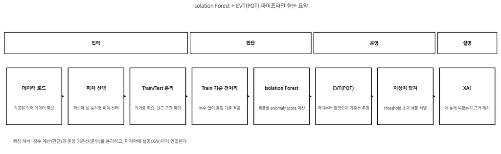

```python
# [Visual] 파이프라인 흐름도

steps = [
    ("입력", "데이터 로드", "가공된 입력 데이터 확보"),
    ("입력", "피처 선택", "학습에 쓸 숫자형 피처 선택"),
    ("입력", "Train/Test 분리", "과거로 학습, 최근 구간 확인"),
    ("판단", "Train 기준 전처리", "누수 없이 동일 기준 적용"),
    ("판단", "Isolation Forest", "샘플별 anomaly score 계산"),
    ("운영", "EVT(POT)", "어디부터 알람인지 기준선 추정"),
    ("운영", "이상치 탐지", "threshold 초과 샘플 식별"),
    ("설명", "XAI", "왜 높게 나왔는지 근거 제시"),
]

fig, ax = plt.subplots(figsize=(16, 5))
ax.set_xlim(0, len(steps))
ax.set_ylim(0, 1.15)
ax.axis("off")

group_ranges = {
    "입력": (0, 3),
    "판단": (3, 5),
    "운영": (5, 7),
    "설명": (7, 8),
}
for group, (start, end) in group_ranges.items():
    ax.add_patch(plt.Rectangle((start + 0.02, 0.82), end - start - 0.04, 0.18, fill=False, linewidth=1.2))
    ax.text((start + end) / 2, 0.91, group, ha="center", va="center", fontsize=11, fontweight="bold")

for i, (_, title, subtitle) in enumerate(steps):
    x = i + 0.05
    rect = plt.Rectangle((x, 0.22), 0.9, 0.48, fill=False, linewidth=1.6)
    ax.add_patch(rect)
    ax.text(x + 0.45, 0.53, title, ha="center", va="center", fontsize=11, fontweight="bold")
    ax.text(x + 0.45, 0.36, subtitle, ha="center", va="center", fontsize=9)
    if i < len(steps) - 1:
        ax.annotate("", xy=(i + 1.0, 0.46), xytext=(i + 0.95, 0.46),
                    arrowprops=dict(arrowstyle="->", linewidth=1.5))

ax.text(
    0.02, 0.06,
    "핵심 해석: 점수 계산(판단)과 운영 기준선(운영)을 분리하고, 마지막에 설명(XAI)까지 연결한다.",
    transform=ax.transAxes, fontsize=10
)

plt.title("Isolation Forest + EVT(POT) 파이프라인 한눈 요약", pad=16)
plt.tight_layout()
plt.show()
```

## 2) Config

이 섹션에서는 데이터 경로, 필터, 전처리 방식, 모델/EVT 설정을 정리합니다.  
나중에 결과를 해석할 때 “왜 이런 값이 나왔는지”를 되짚는 기준이 됩니다.

```python
# [Config] 실행/실험 설정

RUN_TAG = None
OUTPUT_ROOT = "runs"
SAVE_FIGS = False
FIG_DPI = 140

# 입력 데이터
DATA_PATH = "data/sample_features_public.parquet"

# 분석 대상 필터(선택)
FILTER_USER_NAME = None
FILTER_GROUP_ID = None
FILTER_HOST_IP = None

# 피처 선택
FEATURE_WHITELIST = None
FEATURE_WHITELIST_PATH = None
META_COLS = [
    "company_cd", "group_id", "user_name", "host_ip", "ts",
    "spec_version", "policy_hash", "row_hash", "created_at", "window_sec"
]

# 개인정보 / 민감정보 마스킹(출력용)
MASK_PERSONAL_INFO = True
MASK_COLUMNS = ["user_name", "host_ip", "row_hash", "policy_hash"]
SHOW_MASKED_SAMPLE_ROWS = 5

# split
TRAIN_RATIO = 0.8

# 전처리
ADD_MISSING_INDICATOR = False
USE_SIGNED_LOG = True
LOG_TARGET_FEATURES = None
LOG_EXCLUDE_FEATURES = None
LOG_EXCLUDE_KEYWORDS = ["ratio", "rate", "pct", "percent", "prob"]
SCALER_TYPE = "standard"   # robust | standard | none

# model
IF_PARAMS = dict(
    n_estimators=200,
    contamination="auto",
    max_samples="auto",
    random_state=42,
    n_jobs=-1,
)

# EVT
EVT_RISK_LEVEL = 0.0001
EVT_Q_INIT = 0.98
EVT_MIN_PEAKS = 50
EVT_MIN_Q = 0.90
EVT_SHOW_DIAGNOSTICS = True

# XAI
BASELINE_STAT = "mean"  # mean | median
BINARY_BASELINE_MODE = True
RADAR_NORM_QLOW = 0.10
RADAR_NORM_QHIGH = 0.90
TOP_N_FEATURES = 8
XAI_CLIP_MAX = None
SHOW_DISTRIBUTION_PLOTS = True

SHAP_BACKGROUND_SIZE = 200
SHAP_ALGORITHM = "permutation"
SHAP_MAX_EVALS = "auto"
SHAP_BATCH_SIZE = 256
SHAP_SUMMARY_TOPN = 20

# 원본 로그 컨텍스트 결합(선택)
RAW_LOG_PATH = None
RAW_LOG_JOIN_KEYS = ["ts", "company_cd", "group_id", "user_name", "host_ip", "row_hash"]
TRACE_TOPN = 30

print("파라미터 로드 완료")
```

```
파라미터 로드 완료
```

## 3) Run Context & Reproducibility

같은 코드를 다시 실행해도 비슷한 결과를 재현할 수 있도록,  
실행 시점과 라이브러리 버전, 주요 설정을 한 번에 남긴다.

```python
# [Run] 실행 메타데이터 / 설정 스냅샷

from datetime import datetime

RUN_TS = datetime.now().strftime("%Y%m%d_%H%M%S")
RUN_ID = RUN_TS if not RUN_TAG else f"{RUN_TS}_{RUN_TAG}"

OUTPUT_DIR = os.path.join(OUTPUT_ROOT, RUN_ID)
FIG_DIR = os.path.join(OUTPUT_DIR, "figs")
ARTIFACT_DIR = os.path.join(OUTPUT_DIR, "artifacts")

def _safe_version(modname: str) -> str:
    try:
        mod = __import__(modname)
        return getattr(mod, "__version__", "unknown")
    except Exception:
        return "not_installed"

RUN_INFO = {
    "run_id": RUN_ID,
    "run_ts": RUN_TS,
    "python": sys.version.split()[0],
    "platform": platform.platform(),
    "numpy": _safe_version("numpy"),
    "pandas": _safe_version("pandas"),
    "sklearn": _safe_version("sklearn"),
    "scipy": _safe_version("scipy"),
    "shap": _safe_version("shap"),
}

CONFIG_SNAPSHOT = {
    "data_path": DATA_PATH,
    "filters": {
        "user_name": FILTER_USER_NAME,
        "group_id": FILTER_GROUP_ID,
        "host_ip": FILTER_HOST_IP,
    },
    "train_ratio": TRAIN_RATIO,
    "feature_whitelist_used": FEATURE_WHITELIST is not None or FEATURE_WHITELIST_PATH is not None,
    "scaler_type": SCALER_TYPE,
    "add_missing_indicator": ADD_MISSING_INDICATOR,
    "use_signed_log": USE_SIGNED_LOG,
    "if_params": IF_PARAMS,
    "evt": {
        "risk_level": EVT_RISK_LEVEL,
        "q_init": EVT_Q_INIT,
        "min_peaks": EVT_MIN_PEAKS,
        "min_q": EVT_MIN_Q,
        "show_diagnostics": EVT_SHOW_DIAGNOSTICS,
    },
    "xai": {
        "baseline_stat": BASELINE_STAT,
        "binary_baseline_mode": BINARY_BASELINE_MODE,
        "top_n_features": TOP_N_FEATURES,
    },
}

print("RUN_ID:", RUN_ID)
display(pd.DataFrame([CONFIG_SNAPSHOT]))
```

```
RUN_ID: 20260414_150946
```

|  | data_path | filters | train_ratio | feature_whitelist_used | scaler_type | add_missing_indicator | use_signed_log | if_params | evt | xai |
| --- | --- | --- | --- | --- | --- | --- | --- | --- | --- | --- |
| 0 | data/sample_features_public.parquet | {'user_name': None, 'group_id': None, 'host_ip... | 0.8 | False | standard | False | True | {'n_estimators': 200, 'contamination': 'auto',... | {'risk_level': 0.0001, 'q_init': 0.98, 'min_pe... | {'baseline_stat': 'mean', 'binary_baseline_mod... |

## 4) 데이터 로드 / 모델 입력 피처 선택

여기서는 **무엇을 입력으로 삼았는지**를 확인한다.

- 데이터 규모는 어떤가
- 시간 범위는 어떤가
- 실제 학습에 들어간 피처는 무엇인가
- 공유용 출력에서 개인정보가 제대로 가려지는가

즉, 모델보다 먼저 **입력 데이터 상태와 공유 가능 형태**를 확인하는 단계

```python
# [Data] 데이터 로드 & 피처 선택

def _load_feature_whitelist(path):
    if path is None:
        return None
    if not os.path.exists(path):
        raise FileNotFoundError(f"FEATURE_WHITELIST_PATH={path} 파일을 찾을 수 없습니다.")
    if path.lower().endswith(".json"):
        with open(path, "r", encoding="utf-8") as f:
            obj = json.load(f)
        if isinstance(obj, dict) and "features" in obj:
            return list(obj["features"])
        if isinstance(obj, list):
            return list(obj)
        raise ValueError('feature whitelist json은 리스트 또는 {"features":[...]} 형식이어야 합니다.')
    with open(path, "r", encoding="utf-8") as f:
        return [line.strip() for line in f if line.strip()]

if not os.path.exists(DATA_PATH):
    raise FileNotFoundError(
        f"DATA_PATH='{DATA_PATH}' 파일을 찾을 수 없습니다.\n"
        "- 노트북과 parquet 위치를 다시 확인하세요.\n"
        "- 상대경로 대신 절대경로로 지정해도 됩니다."
    )

df = pd.read_parquet(DATA_PATH)
print(f"데이터 로드 성공(원본): {df.shape}")

# 선택 필터
if FILTER_USER_NAME is not None and "user_name" in df.columns:
    df = df[df["user_name"] == FILTER_USER_NAME].copy()
if FILTER_GROUP_ID is not None and "group_id" in df.columns:
    df = df[df["group_id"] == FILTER_GROUP_ID].copy()
if FILTER_HOST_IP is not None and "host_ip" in df.columns:
    df = df[df["host_ip"] == FILTER_HOST_IP].copy()

print(f"필터 적용 후: {df.shape}")

if "ts" in df.columns:
    df["ts"] = pd.to_datetime(df["ts"], errors="coerce")
    df = df.sort_values("ts").reset_index(drop=True)
    print(f"time range: {df['ts'].min()} ~ {df['ts'].max()} | unique_ts={df['ts'].nunique()}")
else:
    print("ts 컬럼이 없어 현재 행 순서 그대로 사용합니다.")

meta_present = [c for c in META_COLS if c in df.columns]

if FEATURE_WHITELIST is None and FEATURE_WHITELIST_PATH is not None:
    FEATURE_WHITELIST = _load_feature_whitelist(FEATURE_WHITELIST_PATH)
    print(f"화이트리스트 로드: {len(FEATURE_WHITELIST)}개")

if FEATURE_WHITELIST is not None:
    wl_present = [c for c in FEATURE_WHITELIST if c in df.columns]
    wl_missing = [c for c in FEATURE_WHITELIST if c not in df.columns]
    if wl_missing:
        print(f"화이트리스트에 있으나 데이터에 없는 컬럼: {len(wl_missing)}개 (예: {wl_missing[:10]})")
    numeric_cols = df[wl_present].select_dtypes(include=[np.number]).columns.tolist()
    non_numeric_wl = [c for c in wl_present if c not in numeric_cols]
    if non_numeric_wl:
        print(f"화이트리스트 중 비수치형이라 제외: {len(non_numeric_wl)}개 (예: {non_numeric_wl[:10]})")
else:
    candidate_cols = [c for c in df.columns if c not in meta_present]
    numeric_cols = df[candidate_cols].select_dtypes(include=[np.number]).columns.tolist()
    non_numeric_cols = [c for c in candidate_cols if c not in numeric_cols]
    print(f"numeric feature 수: {len(numeric_cols)}")
    if non_numeric_cols:
        print(f"제외된 비수치형 컬럼 {len(non_numeric_cols)}개 예시: {non_numeric_cols[:10]}")

nunique = df[numeric_cols].nunique(dropna=False)
const_cols = nunique[nunique <= 1].index.tolist()
if const_cols:
    print(f"상수(변화 없음) 컬럼 제거: {len(const_cols)}개 예시: {const_cols[:10]}")
    numeric_cols = [c for c in numeric_cols if c not in const_cols]

X_all = df[numeric_cols].copy()
FEATURES_USED = list(X_all.columns)

print("기본 검증 완료")
print(f"- 결측 포함 피처 수: {(X_all.isna().any()).sum()} / {X_all.shape[1]}")
print(f"- 최종 피처 수: {len(FEATURES_USED)}")
print(f"- 표본 수: {len(X_all)}")

preview_cols = [c for c in [
    "company_cd", "group_id", "user_name", "host_ip", "ts", "window_sec",
    "row_hash", "policy_hash"
] if c in df.columns]
preview_cols += [c for c in FEATURES_USED[:8] if c not in preview_cols]

if len(preview_cols) > 0:
    display_masked(
        df[preview_cols],
        head=SHOW_MASKED_SAMPLE_ROWS,
        caption="원본 df는 유지하고, 화면 출력 시에만 개인정보/해시 컬럼을 마스킹.",
        mask_columns=MASK_COLUMNS,
        enable=MASK_PERSONAL_INFO,
    )
```

```
데이터 로드 성공(원본): (1367826, 70)
필터 적용 후: (1367826, 70)
time range: 2025-09-30 14:59:00+00:00 ~ 2026-02-12 08:53:00+00:00 | unique_ts=183194
numeric feature 수: 60
상수(변화 없음) 컬럼 제거: 8개 예시: ['cnt_shell_exec', 'cnt_risk_forbid', 'cnt_risk_high', 'cnt_risk_abnormal', 'max_severity_rank', 'ratio_risk_density', 'cnt_sensitive_target', 'ratio_sensitive_write_bytes']
기본 검증 완료
- 결측 포함 피처 수: 3 / 52
- 최종 피처 수: 52
- 표본 수: 1367826
원본 df는 유지하고, 화면 출력 시에만 개인정보/해시 컬럼을 마스킹.
```

|  | company_cd | group_id | user_name | host_ip | ts | window_sec | row_hash | policy_hash | io_bytes_per_sec | net_bytes_per_sec | cnt_file_create | cnt_file_del | cnt_file_write | cnt_file_rename | cnt_file_attach | cnt_proc_exec |
| --- | --- | --- | --- | --- | --- | --- | --- | --- | --- | --- | --- | --- | --- | --- | --- | --- |
| 0 | 회사1 | 그룹1 | 사용자1 | 호스트IP1 | 시점1 | 60.0 | HASH_마스킹 | HASH_마스킹 | 0.0 | 0.0 | 0.0 | 0.0 | 0.0 | 0.0 | 0.0 | 0.0 |
| 1 | 회사1 | 그룹2 | 사용자2 | 호스트IP1 | 시점1 | 60.0 | HASH_마스킹 | HASH_마스킹 | 2964.0 | 2667.0 | 0.0 | 0.0 | 37.0 | 0.0 | 0.0 | 0.0 |
| 2 | 회사1 | 그룹3 | 사용자3 | 호스트IP1 | 시점1 | 60.0 | HASH_마스킹 | HASH_마스킹 | 7.0 | 0.0 | 0.0 | 0.0 | 1.0 | 0.0 | 0.0 | 0.0 |
| 3 | 회사1 | 그룹4 | 사용자4 | 호스트IP2 | 시점2 | 60.0 | HASH_마스킹 | HASH_마스킹 | 0.0 | 2192.0 | 0.0 | 0.0 | 0.0 | 0.0 | 0.0 | 0.0 |
| 4 | 회사1 | 그룹5 | 사용자1 | 호스트IP2 | 시점2 | 60.0 | HASH_마스킹 | HASH_마스킹 | 4304.0 | 0.0 | 1.0 | 2.0 | 3.0 | 0.0 | 0.0 | 1.0 |

```
[이 섹션에서 볼 것] 입력 데이터 상태
 - 데이터 크기와 시간 범위를 먼저 확인합니다.
 - 결측이 특정 피처에 몰려 있는지 봅니다.
 - 일별 row volume이 급격히 흔들리면 score 해석에도 영향을 줄 수 있습니다.
```

|  | 전체 row 수 | 사용 피처 수 | 존재하는 메타 컬럼 수 | 결측 포함 피처 수 | 시작 시각 | 종료 시각 |
| --- | --- | --- | --- | --- | --- | --- |
| 0 | 1367826 | 52 | 10 | 3 | 2025-09-30 14:59:00+00:00 | 2026-02-12 08:53:00+00:00 |

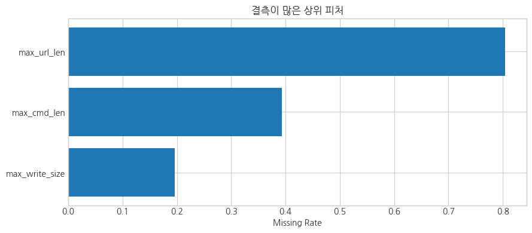

```
[한 줄 결론] 결측이 가장 많은 피처는 max_url_len (80.36%) 입니다.
```

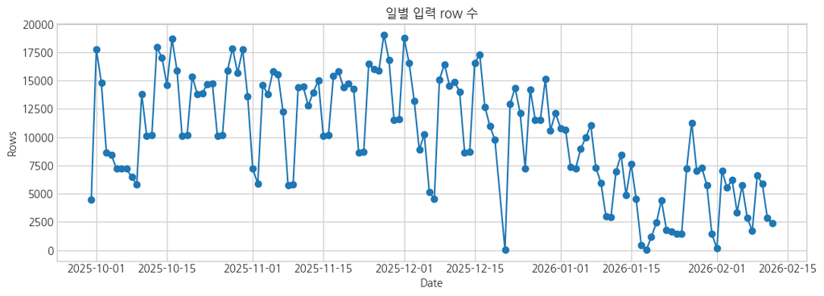

```
[한 줄 결론] 하루 평균 입력 row 수는 10132.0건입니다.
```

```python
# [Visual] 데이터 프로파일 요약
# 문서에 넣기 좋은 보조 시각화:
# 1) 결측 상위 피처
# 2) 일별 row volume (ts가 있을 때)
# 3) 간단 요약표

section_note("입력 데이터 상태", [
    "데이터 크기와 시간 범위를 먼저 확인합니다.",
    "결측이 특정 피처에 몰려 있는지 봅니다.",
    "일별 row volume이 급격히 흔들리면 score 해석에도 영향을 줄 수 있습니다.",
])

profile = pd.DataFrame([{
    "전체 row 수": len(df),
    "사용 피처 수": len(FEATURES_USED),
    "존재하는 메타 컬럼 수": len(meta_present),
    "결측 포함 피처 수": int(X_all.isna().any().sum()),
    "시작 시각": df["ts"].min() if "ts" in df.columns else None,
    "종료 시각": df["ts"].max() if "ts" in df.columns else None,
}])
display(profile)

missing_rate = X_all.isna().mean().sort_values(ascending=False)
missing_top = missing_rate[missing_rate > 0].head(15)

if len(missing_top) > 0:
    plt.figure(figsize=(9, 4))
    plt.barh(missing_top.index[::-1], missing_top.values[::-1])
    plt.title("결측이 많은 상위 피처")
    plt.xlabel("Missing Rate")
    plt.tight_layout()
    plt.show()
    one_liner(f"결측이 가장 많은 피처는 {missing_top.index[0]} ({missing_top.iloc[0]:.2%}) 입니다.")
else:
    print("결측 피처가 없어 missing-rate 그래프를 생략합니다.")

if "ts" in df.columns:
    tmp = df.dropna(subset=["ts"]).copy()
    if len(tmp) > 0:
        tmp["_date"] = tmp["ts"].dt.date
        daily_rows = tmp.groupby("_date").size()
        plt.figure(figsize=(11, 4))
        plt.plot(daily_rows.index, daily_rows.values, marker="o")
        plt.title("일별 입력 row 수")
        plt.xlabel("Date")
        plt.ylabel("Rows")
        plt.tight_layout()
        plt.show()

        one_liner(f"하루 평균 입력 row 수는 {daily_rows.mean():.1f}건입니다.")
```

## 5) 시계열 기준 Train/Test 분리 / Train 기준 전처리

여기서는 데이터를 과거와 최근 구간으로 나누고, 전처리를 **Train 기준으로만 학습**합니다.

핵심은 성능보다 먼저 **정합성**입니다.

- 시간 순서를 깨지 않는다
- Test 정보를 Train에 섞지 않는다
- 같은 기준을 Test에도 적용한다

```python
# [Preprocess] 시계열 기준 Train/Test 분리 + Train 기준 전처리

def signed_log(x):
    return np.sign(x) * np.log1p(np.abs(x))

def make_scaler(kind: str):
    if kind is None:
        return None, "none"
    kind = str(kind).strip().lower()
    if kind == "robust":
        return RobustScaler(), "robust"
    if kind == "standard":
        return StandardScaler(), "standard"
    if kind in ("none", "identity", "no"):
        return None, "none"
    raise ValueError(f"지원하지 않는 SCALER_TYPE={kind}")

n = len(X_all)
if n < 50:
    print(f"표본 수가 매우 적습니다(n={n}). EVT/모델 안정성이 떨어질 수 있습니다.")

train_size = int(n * TRAIN_RATIO)

X_train_raw = X_all.iloc[:train_size].copy()
X_test_raw = X_all.iloc[train_size:].copy()

df_train = df.iloc[:train_size].copy()
df_test = df.iloc[train_size:].copy()

print(f"Train: {X_train_raw.shape}, Test: {X_test_raw.shape}")

missing_cols = X_train_raw.columns[X_train_raw.isna().any()].tolist()
if ADD_MISSING_INDICATOR and len(missing_cols) > 0:
    X_train_ind = X_train_raw[missing_cols].isna().astype(int).add_prefix("isnull_")
    X_test_ind = X_test_raw[missing_cols].isna().astype(int).add_prefix("isnull_")
    print(f"결측 indicator 추가: {X_train_ind.shape[1]}개")
else:
    X_train_ind, X_test_ind = None, None
    print("결측 indicator 미사용 또는 Train 결측 없음")

imputer = SimpleImputer(strategy="median")
X_train_imp = pd.DataFrame(imputer.fit_transform(X_train_raw), columns=X_train_raw.columns, index=X_train_raw.index)
X_test_imp = pd.DataFrame(imputer.transform(X_test_raw), columns=X_test_raw.columns, index=X_test_raw.index)

log_exclude, log_target = [], []
if USE_SIGNED_LOG:
    cols = list(X_train_imp.columns)
    if LOG_TARGET_FEATURES is not None:
        log_target = [c for c in LOG_TARGET_FEATURES if c in cols]
        log_exclude = [c for c in cols if c not in log_target]
    else:
        excl = set()
        if LOG_EXCLUDE_FEATURES is not None:
            excl |= {c for c in LOG_EXCLUDE_FEATURES if c in cols}
        if LOG_EXCLUDE_KEYWORDS is not None:
            excl |= {c for c in cols if any(k in c.lower() for k in LOG_EXCLUDE_KEYWORDS)}
        log_exclude = sorted(list(excl))
        log_target = [c for c in cols if c not in excl]

    if len(log_target) > 0:
        X_train_imp[log_target] = X_train_imp[log_target].apply(signed_log)
        X_test_imp[log_target] = X_test_imp[log_target].apply(signed_log)
        print(f"SignedLog 적용: {len(log_target)}개 (제외: {len(log_exclude)}개)")
    else:
        print("SignedLog 적용 대상이 없어 생략합니다.")
else:
    print("SignedLog 미사용")

if X_train_ind is not None:
    X_train_feat = pd.concat([X_train_imp, X_train_ind], axis=1)
    X_test_feat = pd.concat([X_test_imp, X_test_ind], axis=1)
else:
    X_train_feat, X_test_feat = X_train_imp, X_test_imp

# XAI 용: scaling 전 전처리 공간
X_train_pre = X_train_feat.copy()
X_test_pre = X_test_feat.copy()

scaler, scaler_name = make_scaler(SCALER_TYPE)
if scaler is None:
    X_train, X_test = X_train_feat, X_test_feat
    print("Scaling 미사용")
else:
    X_train = pd.DataFrame(scaler.fit_transform(X_train_feat), columns=X_train_feat.columns, index=X_train_feat.index)
    X_test = pd.DataFrame(scaler.transform(X_test_feat), columns=X_test_feat.columns, index=X_test_feat.index)
    print(f"Scaling 적용: {scaler_name}")

preprocess_info = {
    "missing_cols": missing_cols,
    "log_target": log_target,
    "log_exclude": log_exclude,
    "scaler_type": scaler_name,
    "num_features": int(X_train.shape[1]),
}

def _check_finite(dfX: pd.DataFrame, name: str):
    arr = dfX.to_numpy()
    if not np.isfinite(arr).all():
        n_bad = int((~np.isfinite(arr)).sum())
        raise ValueError(f"[{name}] 비유한값 발견: {n_bad}개")
    print(f"[{name}] finite 체크 통과")

_check_finite(X_train, "X_train")
_check_finite(X_test, "X_test")
print("전처리 완료")
```

```
Train: (1094260, 52), Test: (273566, 52)
결측 indicator 미사용 또는 Train 결측 없음
SignedLog 적용: 37개 (제외: 15개)
Scaling 적용: standard
[X_train] finite 체크 통과
[X_test] finite 체크 통과
전처리 완료
```

```
[이 섹션에서 볼 것] Train/Test 분포 차이
 - Train과 Test의 중앙값 위치 차이를 간단히 봅니다.
 - 이 값이 크면 score 분포 이동의 배경일 수 있습니다.
 - 정확한 원인 규명보다는 '어디를 먼저 볼지' 찾는 용도입니다.
```

|  | feature | robust_shift | train_median | test_median | train_iqr |
| --- | --- | --- | --- | --- | --- |
| 16 | ratio_offhour_activity | 1.000000 | 1.000000 | 0.000000 | 1.000000 |
| 31 | uniq_file_ext | 0.557493 | 1.098612 | 1.609438 | 0.916291 |
| 32 | uniq_dir_touched | 0.500000 | 1.098612 | 1.791759 | 1.386294 |
| 51 | max_port_scan_behavior | 0.500000 | 1.386294 | 0.693147 | 1.386294 |
| 44 | ratio_proc_churn | 0.416667 | 0.500000 | 1.000000 | 1.200000 |
| 25 | uniq_file_touched | 0.344794 | 1.609438 | 2.197225 | 1.704748 |
| 36 | avg_file_path_depth | 0.317422 | 2.024382 | 2.159484 | 0.425624 |
| 2 | cnt_file_create | 0.251930 | 0.693147 | 1.098612 | 1.609438 |
| 30 | ratio_private_ip | 0.237780 | 0.187500 | 0.263157 | 0.318181 |
| 22 | avg_write_chunk_size | 0.207126 | 8.222033 | 9.420581 | 5.786566 |
| 4 | cnt_file_write | 0.180103 | 1.791759 | 2.197225 | 2.251292 |
| 28 | uniq_dest_port | 0.163171 | 2.197225 | 1.791759 | 2.484907 |
| 49 | ratio_sabotage_ops | 0.150376 | 0.210526 | 0.142857 | 0.450000 |
| 23 | cv_write_chunk_size | 0.144005 | 0.634221 | 0.795520 | 1.120096 |
| 33 | avg_filename_entropy | 0.116290 | 0.269301 | 0.258720 | 0.090988 |

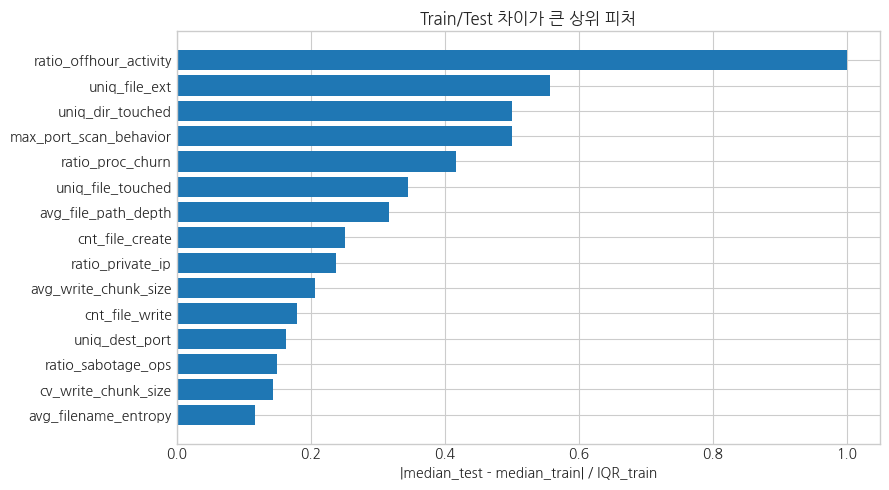

```
[한 줄 결론] 가장 크게 이동한 피처는 ratio_offhour_activity (shift=1.00) 입니다.
```

```python
# [Visual] Train/Test feature shift snapshot
# 설명 문서에서 "분포 이동"을 보조 설명할 때 쓰기 좋은 그림

section_note("Train/Test 분포 차이", [
    "Train과 Test의 중앙값 위치 차이를 간단히 봅니다.",
    "이 값이 크면 score 분포 이동의 배경일 수 있습니다.",
    "정확한 원인 규명보다는 '어디를 먼저 볼지' 찾는 용도입니다.",
])

def robust_shift(train_s: pd.Series, test_s: pd.Series):
    tr_med = float(np.nanmedian(train_s))
    te_med = float(np.nanmedian(test_s))
    q1, q3 = np.nanpercentile(train_s, [25, 75])
    iqr = float(q3 - q1)
    if not np.isfinite(iqr) or iqr == 0:
        iqr = float(np.nanstd(train_s))
    if not np.isfinite(iqr) or iqr == 0:
        iqr = 1.0
    return abs(te_med - tr_med) / iqr, tr_med, te_med, iqr

shift_rows = []
for col in X_train_pre.columns:
    s, tr_med, te_med, iqr = robust_shift(X_train_pre[col], X_test_pre[col])
    shift_rows.append({
        "feature": col,
        "robust_shift": float(s),
        "train_median": tr_med,
        "test_median": te_med,
        "train_iqr": iqr,
    })

shift_df = pd.DataFrame(shift_rows).sort_values("robust_shift", ascending=False)
display(shift_df.head(15))

top_shift = shift_df.head(15).iloc[::-1]
plt.figure(figsize=(9, 5))
plt.barh(top_shift["feature"], top_shift["robust_shift"])
plt.title("Train/Test 차이가 큰 상위 피처")
plt.xlabel("|median_test - median_train| / IQR_train")
plt.tight_layout()
plt.show()

if len(shift_df) > 0:
    one_liner(f"가장 크게 이동한 피처는 {shift_df.iloc[0]['feature']} (shift={shift_df.iloc[0]['robust_shift']:.2f}) 입니다.")
```

## 6) Isolation Forest 학습 / anomaly score 계산

이 단계에서 각 샘플은 **얼마나 이상한가**를 하나의 점수로 받습니다.

- 점수가 클수록 더 이상하다
- 점수가 작을수록 상대적으로 정상에 가깝다

즉, 이 섹션은 **판단 점수 만들기** 단계입니다.

```python
# [Model] Isolation Forest 학습 및 anomaly score 계산

section_note("이상 점수 만들기", [
    "Train 데이터로 정상 패턴의 기준을 학습합니다.",
    "anomaly_score는 값이 클수록 더 이상하다는 뜻으로 방향을 맞춥니다.",
    "이 단계에서는 아직 운영 threshold를 정하지 않습니다.",
])

model = IsolationForest(**IF_PARAMS)
model.fit(X_train)

train_scores = -model.score_samples(X_train)
test_scores = -model.score_samples(X_test)

df_train["anomaly_score"] = train_scores
df_test["anomaly_score"] = test_scores

print("모델 학습 완료")
print(f"scaler_type: {preprocess_info.get('scaler_type')}")
print(f"Train Score Mean: {train_scores.mean():.4f} | Std: {train_scores.std():.4f}")
print(f"Test  Score Mean: {test_scores.mean():.4f} | Std: {test_scores.std():.4f}")
one_liner("이 단계의 출력은 '얼마나 이상한가'를 나타내는 점수이며, 실제 알람 기준선은 다음 섹션에서 정합니다.")
```

```
[이 섹션에서 볼 것] 이상 점수 만들기
 - Train 데이터로 정상 패턴의 기준을 학습합니다.
 - anomaly_score는 값이 클수록 더 이상하다는 뜻으로 방향을 맞춥니다.
 - 이 단계에서는 아직 운영 threshold를 정하지 않습니다.
모델 학습 완료
scaler_type: standard
Train Score Mean: 0.4337 | Std: 0.0420
Test  Score Mean: 0.4580 | Std: 0.0546
[한 줄 결론] 이 단계의 출력은 '얼마나 이상한가'를 나타내는 점수이며, 실제 알람 기준선은 다음 섹션에서 정합니다.
```

## 7) EVT(POT)로 운영 threshold 추정

Isolation Forest 점수는 상대 비교에는 좋지만, 그 자체가 바로 **운영 알람 기준선**은 아닙니다.

그래서 이 섹션에서는 Train score의 상단 tail을 보고, EVT(POT)로 **어디부터 알람으로 볼지**를 추정합니다.

```
[이 섹션에서 볼 것] 운영 기준선 정하기
 - Isolation Forest 점수는 상대 비교에 강합니다.
 - 운영에서는 어디부터 알람인지 별도 기준선이 필요합니다.
 - EVT는 Train score의 상단 꼬리를 이용해 그 기준선을 추정합니다.
EVT 임계값 계산 완료
- used q: 0.98
- tail count nu: 21886 / 1094260
- u (base threshold): 0.5558
- shape: -0.23483842027907695 | scale: 0.048292565414472285
- FINAL threshold (risk=0.0001): 0.7022
[읽는 법] EVT threshold는 Train tail을 기준으로 잡은 운영선입니다. 따라서 configured risk와 실제 Test alarm rate는 달라질 수 있습니다.
[한 줄 결론] 여기서의 risk는 Train tail 기준 운영선 설정값입니다. 실제 Test alarm rate와 같다고 가정하면 안 됩니다.
Test anomalies: 96 / 273566 (0.0351%)
```

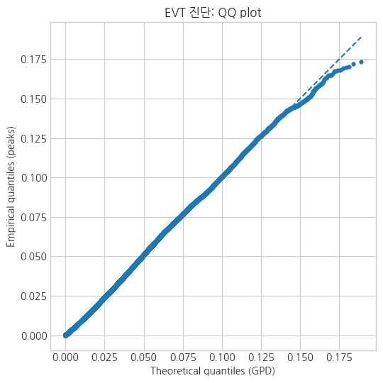

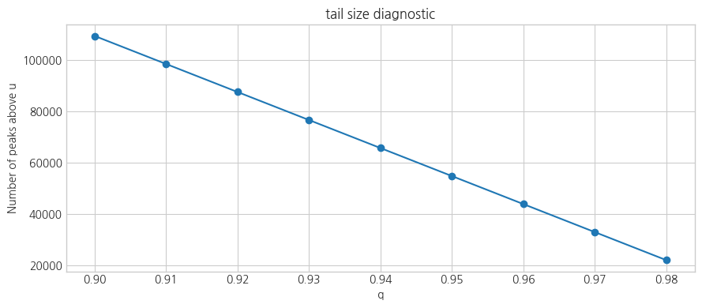

```python
# [EVT] POT(GPD) 기반 운영 threshold 추정

section_note("운영 기준선 정하기", [
    "Isolation Forest 점수는 상대 비교에 강합니다.",
    "운영에서는 어디부터 알람인지 별도 기준선이 필요합니다.",
    "EVT는 Train score의 상단 꼬리를 이용해 그 기준선을 추정합니다.",
])

def calc_pot_threshold(scores, risk=1e-3, q_init=0.98, min_peaks=50, min_q=0.90, eps=1e-6):
    scores = np.asarray(scores)
    n = len(scores)

    q = q_init
    nu = 0
    u = np.percentile(scores, q * 100)

    while q >= min_q:
        u = np.percentile(scores, q * 100)
        peaks = scores[scores > u] - u
        nu = len(peaks)
        if nu >= min_peaks:
            break
        q -= 0.01

    if nu < min_peaks:
        return u, u, np.nan, np.nan, nu, q, True

    peaks = scores[scores > u] - u
    shape, loc, scale = genpareto.fit(peaks, floc=0)

    base = (risk * n) / nu
    if (base <= 0) or (base >= 1):
        return u, u, shape, scale, nu, q, True

    if abs(shape) > eps:
        th = u + (scale / shape) * (base ** (-shape) - 1)
    else:
        th = u - scale * np.log(base)

    return th, u, shape, scale, nu, q, False

threshold, u_val, shape, scale, nu, used_q, used_fallback = calc_pot_threshold(
    train_scores,
    risk=EVT_RISK_LEVEL,
    q_init=EVT_Q_INIT,
    min_peaks=EVT_MIN_PEAKS,
    min_q=EVT_MIN_Q,
)

print("EVT 임계값 계산 완료")
print(f"- used q: {used_q:.2f}")
print(f"- tail count nu: {nu} / {len(train_scores)}")
print(f"- u (base threshold): {u_val:.4f}")
print(f"- shape: {shape} | scale: {scale}")
print(f"- FINAL threshold (risk={EVT_RISK_LEVEL}): {threshold:.4f}")
if used_fallback:
    print("tail 샘플 부족 또는 수식 불안정으로 fallback(u)을 사용했습니다.")

how_to_read("evt")
one_liner("여기서의 risk는 Train tail 기준 운영선 설정값입니다. 실제 Test alarm rate와 같다고 가정하면 안 됩니다.")

df_test["is_anomaly"] = df_test["anomaly_score"] > threshold
num_anomalies = int(df_test["is_anomaly"].sum())
alarm_rate = num_anomalies / max(1, len(df_test))
print(f"Test anomalies: {num_anomalies} / {len(df_test)} ({alarm_rate*100:.4f}%)")

if EVT_SHOW_DIAGNOSTICS and (not used_fallback) and np.isfinite(shape) and np.isfinite(scale):
    peaks = np.asarray(train_scores[train_scores > u_val] - u_val)
    peaks_sorted = np.sort(peaks)
    p = (np.arange(1, len(peaks_sorted) + 1) - 0.5) / len(peaks_sorted)
    theo_q = genpareto.ppf(p, c=shape, loc=0, scale=scale)

    plt.figure(figsize=(5.5, 5.5))
    plt.scatter(theo_q, peaks_sorted, s=12)
    mx = max(np.max(theo_q), np.max(peaks_sorted))
    plt.plot([0, mx], [0, mx], linestyle="--")
    plt.title("EVT 진단: QQ plot")
    plt.xlabel("Theoretical quantiles (GPD)")
    plt.ylabel("Empirical quantiles (peaks)")
    plt.tight_layout()
    plt.show()

    qs = np.arange(max(EVT_MIN_Q, 0.80), min(EVT_Q_INIT, 0.995) + 1e-9, 0.01)
    nus, us = [], []
    for qq in qs:
        uu = np.percentile(train_scores, qq * 100)
        nus.append(int((train_scores > uu).sum()))
        us.append(float(uu))

    plt.figure(figsize=(9, 4))
    plt.plot(qs, nus, marker="o")
    plt.title("tail size diagnostic")
    plt.xlabel("q")
    plt.ylabel("Number of peaks above u")
    plt.tight_layout()
    plt.show()
```

## 8) Test 구간 이상치 탐지 / 결과 해석

이제 최근 구간(Test)에 threshold를 적용해 실제 이상치 후보를 찾습니다.

이 섹션에서는 아래를 함께 봅니다.

- Test 분포가 Train보다 오른쪽으로 이동했는가
- threshold를 넘는 샘플이 특정 시점에 몰리는가
- 최근 구간에서 운영 부담이 커졌는가

```
[이 섹션에서 볼 것] 탐지 결과 읽기
 - Train/Test score 분포 차이를 먼저 봅니다.
 - threshold를 넘는 구간이 특정 시점에 몰리는지 확인합니다.
 - KS 검정은 참고 지표로 보고, p-value만 단독 해석하지 않습니다.
```

|  | run_id | data_path | scaler_type | n_train | n_test | n_features | evt_risk_level | evt_used_q | evt_tail_nu | threshold | test_anomalies | test_alarm_rate | train_score_mean | test_score_mean |
| --- | --- | --- | --- | --- | --- | --- | --- | --- | --- | --- | --- | --- | --- | --- |
| 0 | 20260414_150946 | data/sample_features_public.parquet | standard | 1094260 | 273566 | 52 | 0.0001 | 0.98 | 21886 | 0.702155 | 96 | 0.000351 | 0.433725 | 0.458006 |

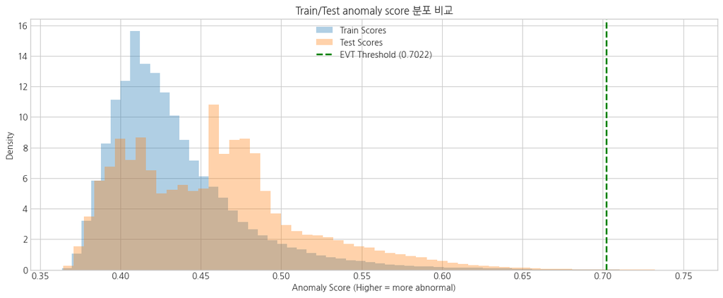

```
[읽는 법] Test 분포가 Train보다 오른쪽으로 가면 최근 구간에서 더 이상하거나 분포 변화가 있을 수 있습니다. threshold 오른쪽 면적이 실제 알람 부담입니다.
[한 줄 결론] Score 중앙값: Train=0.4236, Test=0.4563 (Δ=+0.03266) → 우측 이동(이상 증가)
```

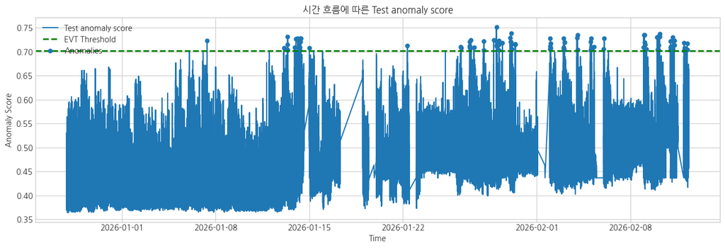

```
KS test p-value=0 | statistic=0.290
[한 줄 결론] KS p-value=0, stat=0.290 → 드리프트 가능성 높음
참고: 표본 수가 크면 작은 차이도 유의하게 나올 수 있으므로, 분포 이동 크기와 실제 알람 부담을 함께 해석하세요.
```

```python
# [Evaluation] 분포 비교 + 시간 흐름 + KS test

section_note("탐지 결과 읽기", [
    "Train/Test score 분포 차이를 먼저 봅니다.",
    "threshold를 넘는 구간이 특정 시점에 몰리는지 확인합니다.",
    "KS 검정은 참고 지표로 보고, p-value만 단독 해석하지 않습니다.",
])

summary = {
    "run_id": RUN_ID,
    "data_path": DATA_PATH,
    "scaler_type": preprocess_info.get("scaler_type"),
    "n_train": int(len(df_train)),
    "n_test": int(len(df_test)),
    "n_features": int(preprocess_info.get("num_features")),
    "evt_risk_level": float(EVT_RISK_LEVEL),
    "evt_used_q": float(used_q),
    "evt_tail_nu": int(nu),
    "threshold": float(threshold),
    "test_anomalies": int(num_anomalies),
    "test_alarm_rate": float(alarm_rate),
    "train_score_mean": float(np.mean(train_scores)),
    "test_score_mean": float(np.mean(test_scores)),
}
display(pd.DataFrame([summary]))

plt.figure(figsize=(12, 5))
plt.hist(train_scores, bins=60, density=True, alpha=0.35, label="Train Scores")
plt.hist(test_scores, bins=60, density=True, alpha=0.35, label="Test Scores")
plt.axvline(threshold, color="green", linestyle="--", linewidth=2, label=f"EVT Threshold ({threshold:.4f})")
plt.title("Train/Test anomaly score 분포 비교")
plt.xlabel("Anomaly Score (Higher = more abnormal)")
plt.ylabel("Density")
plt.legend()
plt.tight_layout()
plt.show()

how_to_read("distribution")
med_train = float(np.median(train_scores))
med_test = float(np.median(test_scores))
delta = med_test - med_train
direction = "우측 이동(이상 증가)" if delta > 0 else ("좌측 이동(이상 감소)" if delta < 0 else "변화 없음")
one_liner(f"Score 중앙값: Train={med_train:.4g}, Test={med_test:.4g} (Δ={delta:+.4g}) → {direction}")

if "ts" in df_test.columns:
    plt.figure(figsize=(13, 4.5))
    plt.plot(df_test["ts"], df_test["anomaly_score"], label="Test anomaly score")
    plt.axhline(threshold, color="green", linestyle="--", linewidth=2, label="EVT Threshold")
    if num_anomalies > 0:
        anom = df_test[df_test["is_anomaly"]]
        plt.scatter(anom["ts"], anom["anomaly_score"], s=25, label="Anomalies")
    plt.title("시간 흐름에 따른 Test anomaly score")
    plt.xlabel("Time")
    plt.ylabel("Anomaly Score")
    plt.legend()
    plt.tight_layout()
    plt.show()

ks = ks_2samp(train_scores, test_scores)
print(f"KS test p-value={ks.pvalue:.3g} | statistic={ks.statistic:.3f}")
if np.isfinite(ks.pvalue):
    drift_msg = "드리프트 가능성 높음" if ks.pvalue < 0.01 else ("주의(약한 변화)" if ks.pvalue < 0.05 else "뚜렷하지 않음")
    one_liner(f"KS p-value={ks.pvalue:.3g}, stat={ks.statistic:.3f} → {drift_msg}")
    print("참고: 표본 수가 크면 작은 차이도 유의하게 나올 수 있으므로, 분포 이동 크기와 실제 알람 부담을 함께 해석하세요.")
```

```
[이 섹션에서 볼 것] 운영 시각화
 - 이상치가 특정 날짜에 몰리는지 봅니다.
 - 이벤트성 이상인지, 산발적 노이즈인지 구분하는 데 도움이 됩니다.
```

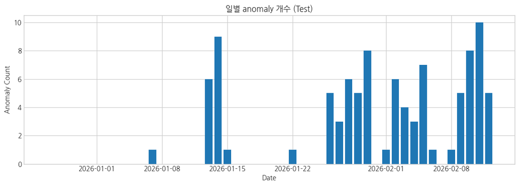

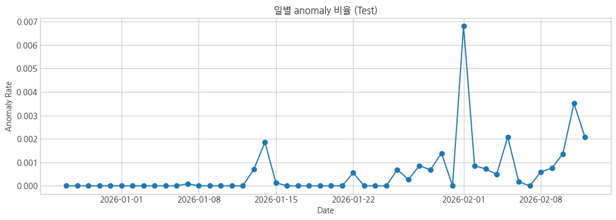

```
[한 줄 결론] 이상치가 가장 많이 발생한 날짜는 2026-02-11이며 10건입니다.
```

```python
# [Visual] 운영 해석을 돕는 추가 시각화
# 1) 일별 anomaly count
# 2) threshold 초과율을 시간 단위로 보기

section_note("운영 시각화", [
    "이상치가 특정 날짜에 몰리는지 봅니다.",
    "이벤트성 이상인지, 산발적 노이즈인지 구분하는 데 도움이 됩니다.",
])

if "ts" in df_test.columns and num_anomalies > 0:
    tmp = df_test.dropna(subset=["ts"]).copy()
    tmp["ts"] = pd.to_datetime(tmp["ts"], errors="coerce")
    tmp = tmp.dropna(subset=["ts"])
    tmp["_date"] = tmp["ts"].dt.date

    daily_counts = tmp.groupby("_date")["is_anomaly"].sum()
    daily_rate = tmp.groupby("_date")["is_anomaly"].mean()

    plt.figure(figsize=(11, 4))
    plt.bar(daily_counts.index, daily_counts.values)
    plt.title("일별 anomaly 개수 (Test)")
    plt.xlabel("Date")
    plt.ylabel("Anomaly Count")
    plt.tight_layout()
    plt.show()

    plt.figure(figsize=(11, 4))
    plt.plot(daily_rate.index, daily_rate.values, marker="o")
    plt.title("일별 anomaly 비율 (Test)")
    plt.xlabel("Date")
    plt.ylabel("Anomaly Rate")
    plt.tight_layout()
    plt.show()

    peak_day = daily_counts.sort_values(ascending=False).index[0]
    peak_cnt = int(daily_counts.sort_values(ascending=False).iloc[0])
    one_liner(f"이상치가 가장 많이 발생한 날짜는 {peak_day}이며 {peak_cnt}건입니다.")
else:
    print("ts 또는 anomaly가 부족해 일별 anomaly 시각화를 생략합니다.")
```

## 9) 운영 해석: risk / alarm_rate / 민감도

운영에서는 비율보다 **실제 알람 부담**이 더 중요합니다.

그래서 이 섹션에서는 아래를 함께 봅니다.

- 설정한 risk
- 실제 Test alarm rate
- 하루/시간 기준 예상 알람 수

```
[이 섹션에서 볼 것] 민감도 확인
 - 설정 risk를 바꾸면 실제 Test alarm rate가 어떻게 변하는지 봅니다.
 - risk와 alarm_rate가 크게 벌어지면 최근 구간 분포 변화 가능성을 의심합니다.
```

|  | risk | threshold | alarm_rate_test | nu_tail | used_q | fallback |
| --- | --- | --- | --- | --- | --- | --- |
| 0 | 0.000100 | 0.702155 | 0.000351 | 21886 | 0.98 | False |
| 1 | 0.000178 | 0.693578 | 0.000567 | 21886 | 0.98 | False |
| 2 | 0.000316 | 0.683759 | 0.000844 | 21886 | 0.98 | False |
| 3 | 0.000562 | 0.672519 | 0.001404 | 21886 | 0.98 | False |
| 4 | 0.001000 | 0.659652 | 0.002394 | 21886 | 0.98 | False |
| 5 | 0.001778 | 0.644923 | 0.004142 | 21886 | 0.98 | False |
| 6 | 0.003162 | 0.628061 | 0.007512 | 21886 | 0.98 | False |
| 7 | 0.005623 | 0.608759 | 0.013839 | 21886 | 0.98 | False |
| 8 | 0.010000 | 0.586663 | 0.027598 | 21886 | 0.98 | False |

[output not shown]

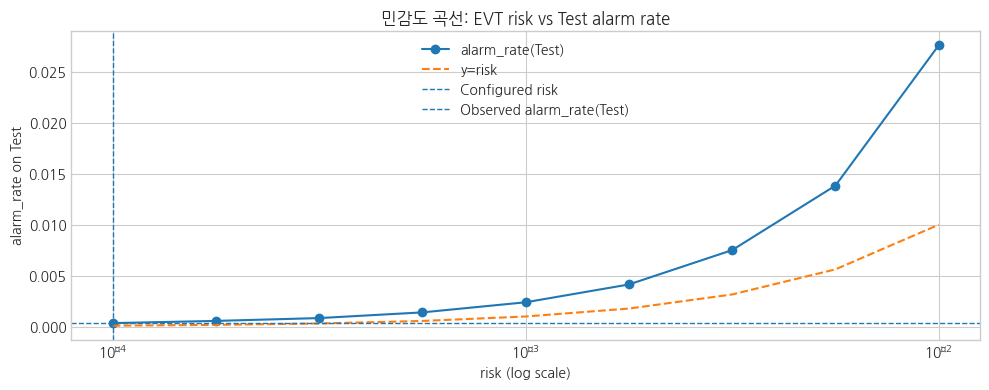

```
[읽는 법] y=risk 참고선보다 alarm_rate(Test)가 높으면 Train 기준으로 잡은 운영선이 최근 구간에서는 더 빡빡하거나 분포 변화가 있을 수 있습니다.
[한 줄 결론] Configured risk=0.0001 대비 Test alarm_rate=0.0351% → 3.51배
```

```python
# [Sensitivity] risk ↔ alarm_rate(Test)

section_note("민감도 확인", [
    "설정 risk를 바꾸면 실제 Test alarm rate가 어떻게 변하는지 봅니다.",
    "risk와 alarm_rate가 크게 벌어지면 최근 구간 분포 변화 가능성을 의심합니다.",
])

risk_grid = np.logspace(-4, -2, 9)
records = []
for r in risk_grid:
    th_r, u_r, shape_r, scale_r, nu_r, used_q_r, fb_r = calc_pot_threshold(
        train_scores, risk=float(r), q_init=EVT_Q_INIT, min_peaks=EVT_MIN_PEAKS, min_q=EVT_MIN_Q
    )
    ar_r = float((np.asarray(test_scores) > th_r).mean())
    records.append({
        "risk": float(r),
        "threshold": float(th_r),
        "alarm_rate_test": float(ar_r),
        "nu_tail": int(nu_r),
        "used_q": float(used_q_r),
        "fallback": bool(fb_r),
    })

sens_df = pd.DataFrame(records)
display(sens_df)

plt.figure(figsize=(10, 4))
plt.semilogx(sens_df["risk"], sens_df["alarm_rate_test"], marker="o", label="alarm_rate(Test)")
plt.plot(sens_df["risk"], sens_df["risk"], linestyle="--", label="y=risk")
plt.axvline(float(EVT_RISK_LEVEL), linestyle="--", linewidth=1, label="Configured risk")
plt.axhline(float(alarm_rate), linestyle="--", linewidth=1, label="Observed alarm_rate(Test)")
plt.title("민감도 곡선: EVT risk vs Test alarm rate")
plt.xlabel("risk (log scale)")
plt.ylabel("alarm_rate on Test")
plt.legend()
plt.tight_layout()
plt.show()

how_to_read("sensitivity")
ratio_cfg = float(alarm_rate) / float(EVT_RISK_LEVEL) if float(EVT_RISK_LEVEL) > 0 else np.nan
if np.isfinite(ratio_cfg):
    one_liner(f"Configured risk={float(EVT_RISK_LEVEL):g} 대비 Test alarm_rate={float(alarm_rate):.4%} → {ratio_cfg:.2f}배")
```

```python
# [Risk to Daily/Hourly] 행 단위 risk를 운영 단위로 환산

section_note("운영 부담 환산", [
    "행 단위 비율을 실제 시간/일 기준 알람 건수로 바꿔 봅니다.",
    "row 생성 단위가 안정적일 때 가장 해석하기 좋습니다.",
])

def _rate_table(df_, risk_val, alarm_val):
    if "ts" not in df_.columns:
        return None
    d = df_.dropna(subset=["ts"]).copy()
    d["ts"] = pd.to_datetime(d["ts"], errors="coerce")
    d = d.dropna(subset=["ts"])
    if len(d) == 0:
        return None

    d["_date"] = d["ts"].dt.date
    d["_hour"] = d["ts"].dt.floor("H")

    rows_per_day = d.groupby("_date").size()
    rows_per_hour = d.groupby("_hour").size()

    avg_rows_day = float(rows_per_day.mean()) if len(rows_per_day) else np.nan
    avg_rows_hour = float(rows_per_hour.mean()) if len(rows_per_hour) else np.nan

    exp_day = avg_rows_day * risk_val if np.isfinite(avg_rows_day) and np.isfinite(risk_val) else np.nan
    exp_hour = avg_rows_hour * risk_val if np.isfinite(avg_rows_hour) and np.isfinite(risk_val) else np.nan
    obs_day = avg_rows_day * alarm_val if np.isfinite(avg_rows_day) and np.isfinite(alarm_val) else np.nan
    obs_hour = avg_rows_hour * alarm_val if np.isfinite(avg_rows_hour) and np.isfinite(alarm_val) else np.nan

    return pd.DataFrame([
        {"단위": "시간", "평균 행 수": avg_rows_hour, "예상 알람(risk 기준)": exp_hour, "관측 알람(Test 기준)": obs_hour},
        {"단위": "일", "평균 행 수": avg_rows_day, "예상 알람(risk 기준)": exp_day, "관측 알람(Test 기준)": obs_day},
    ])

tbl = _rate_table(df_test, float(EVT_RISK_LEVEL), float(alarm_rate))
if tbl is not None:
    display(tbl)
    day_row = tbl[tbl["단위"] == "일"].iloc[0]
    one_liner(f"하루 평균 {day_row['평균 행 수']:.0f}행 기준 → risk 기대 {day_row['예상 알람(risk 기준)']:.2f}건 / 실제 {day_row['관측 알람(Test 기준)']:.2f}건")
else:
    print("ts가 없어 일/시간 단위 환산을 계산하지 못했습니다.")
```

```
[이 섹션에서 볼 것] 운영 부담 환산
 - 행 단위 비율을 실제 시간/일 기준 알람 건수로 바꿔 봅니다.
 - row 생성 단위가 안정적일 때 가장 해석하기 좋습니다.
```

|  | 단위 | 평균 행 수 | 예상 알람(risk 기준) | 관측 알람(Test 기준) |
| --- | --- | --- | --- | --- |
| 0 | 시간 | 270.857426 | 0.027086 | 0.09505 |
| 1 | 일 | 5699.291667 | 0.569929 | 2.00000 |

```
[한 줄 결론] 하루 평균 5699행 기준 → risk 기대 0.57건 / 실제 2.00건
```

## 10) SHAP / deviation / percentile 기반 설명

이 섹션은 “왜 이 건이 잡혔는가”를 설명하기 위한 단계입니다.

- **SHAP**: 어떤 피처가 모델 점수를 올렸는가
- **Deviation**: 정상 기준에서 얼마나 멀어졌는가
- **Percentile**: Train 분포 안에서 어느 위치에 있는가

```
[이 섹션에서 볼 것] 설명 결과 읽기
 - SHAP은 모델이 어떤 피처를 많이 사용했는지 보여줍니다.
 - Deviation은 정상 기준에서 얼마나 멀리 벗어났는지 보여줍니다.
 - Percentile radar는 Train 분포 안에서 위치를 직관적으로 보여줍니다.
설명 대상 anomaly 미리보기(공유용 마스킹 적용)
```

|  | ts | company_cd | group_id | user_name | host_ip | anomaly_score |
| --- | --- | --- | --- | --- | --- | --- |
| CASE_001 | 시점3 | 회사1 | 그룹6 | 사용자5 | 호스트IP1 | 0.751937 |
| CASE_002 | 시점4 | 회사1 | 그룹7 | 사용자6 | 호스트IP1 | 0.738496 |
| CASE_003 | 시점5 | 회사1 | 그룹6 | 사용자5 | 호스트IP1 | 0.737989 |
| CASE_004 | 시점6 | 회사1 | 그룹4 | 사용자1 | 호스트IP2 | 0.735275 |
| CASE_005 | 시점7 | 회사1 | 그룹2 | 윤* | 호스트IP1 | 0.735100 |
| CASE_006 | 시점8 | 회사1 | 그룹4 | 사용자1 | 호스트IP2 | 0.734983 |
| CASE_007 | 시점9 | 회사1 | 그룹4 | 사용자1 | 호스트IP2 | 0.732011 |
| CASE_008 | 시점10 | 회사1 | 그룹2 | 사용자6 | 호스트IP1 | 0.731905 |
| CASE_009 | 시점11 | 회사1 | 그룹6 | 사용자5 | 호스트IP1 | 0.731332 |
| CASE_010 | 시점12 | 회사1 | 그룹2 | 윤* | 호스트IP1 | 0.731102 |
| CASE_011 | 시점13 | 회사1 | 그룹5 | 사용자7 | 호스트IP2 | 0.730912 |
| CASE_012 | 시점14 | 회사1 | 그룹2 | 윤* | 호스트IP1 | 0.729557 |
| CASE_013 | 시점15 | 회사1 | 그룹2 | 윤* | 호스트IP1 | 0.729292 |
| CASE_014 | 시점16 | 회사1 | 그룹8 | 사용자1 | 호스트IP1 | 0.728764 |
| CASE_015 | 시점17 | 회사1 | 그룹2 | 윤* | 호스트IP1 | 0.728271 |
| CASE_016 | 시점18 | 회사1 | 그룹1 | 사용자1 | 호스트IP1 | 0.728009 |
| CASE_017 | 시점19 | 회사1 | 그룹6 | 사용자8 | 호스트IP1 | 0.727962 |
| CASE_018 | 시점20 | 회사1 | 그룹2 | 사용자6 | 호스트IP1 | 0.727951 |
| CASE_019 | 시점21 | 회사1 | 그룹9 | 사용자1 | 호스트IP1 | 0.727859 |
| CASE_020 | 시점22 | 회사1 | 그룹2 | 윤* | 호스트IP1 | 0.727851 |

| feature | value | baseline | shap_value | abs_shap | deviation_iqr | percentile_train |
| --- | --- | --- | --- | --- | --- | --- |
| cnt_file_rename | 4.488636 | 0.057589 | 0.022902 | 0.022902 | 11.608578 | 0.998765 |
| cnt_large_write | 6.206576 | 0.031968 | 0.022148 | 0.022148 | 28.624083 | 1.000000 |
| ratio_high_dest_port | 1.186046 | 0.043728 | 0.020655 | 0.020655 | 101.674978 | 0.999995 |
| uniq_new_ext_on_rename | 2.484907 | 0.015606 | 0.017073 | 0.017073 | 18.805906 | 0.999670 |
| cnt_rename_ext_change | 3.713572 | 0.027921 | 0.016307 | 0.016307 | 13.190223 | 0.998789 |
| uniq_file_touched | 9.869724 | 1.607224 | 0.015221 | 0.015221 | 4.846757 | 0.999674 |
| cnt_proc_completed_in_batch | 2.995732 | 0.325441 | 0.012805 | 0.012805 | 3.852416 | 0.991283 |
| max_url_len | 4.143135 | 0.089895 | 0.012481 | 0.012481 | 6.780954 | 0.990148 |

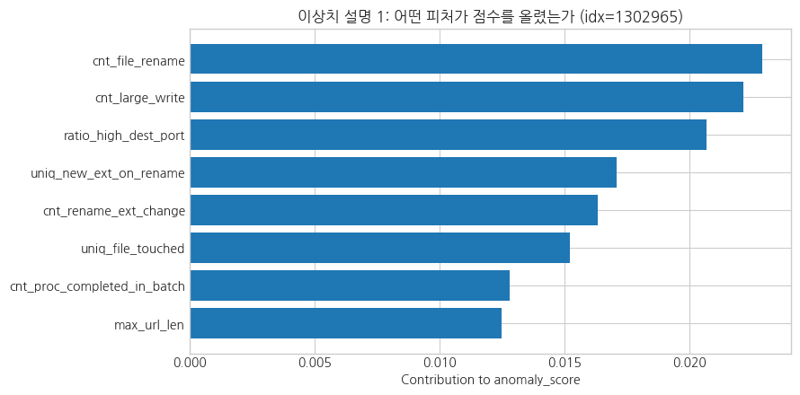

```
[읽는 법] + 기여는 anomaly_score를 올린 피처, - 기여는 낮춘 피처입니다. 이는 모델 판단 근거이지 직접적인 원인 증명은 아닙니다.
[한 줄 결론] 가장 큰 SHAP 기여 피처는 cnt_file_rename 입니다.
```

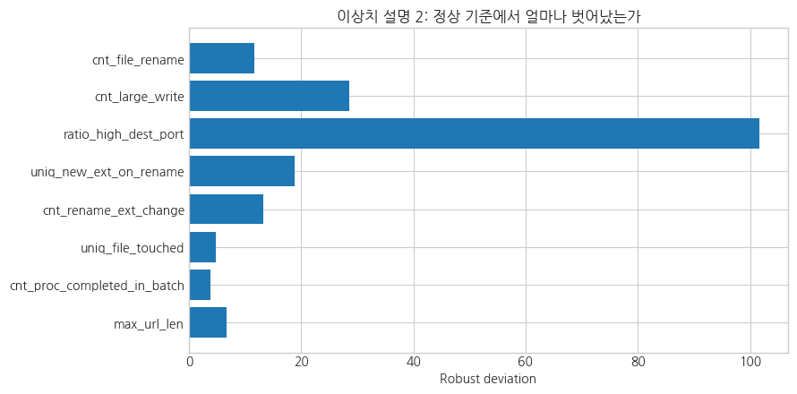

```
[읽는 법] |x-baseline|/IQR 기준 이탈입니다. 값이 클수록 정상 범위에서 더 멀리 벗어났습니다.
[한 줄 결론] baseline 대비 가장 크게 벗어난 피처는 ratio_high_dest_port 입니다.
[읽는 법] Train 분포 내 퍼센타일 위치입니다. 90% 이상/10% 이하는 분포 끝단으로 해석할 수 있습니다.
```

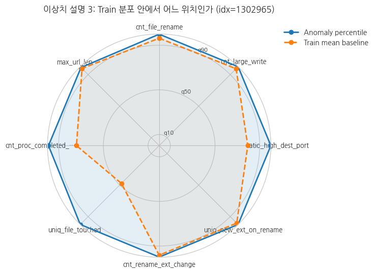

|  | idx | anomaly_score | top3_features_by_shap |
| --- | --- | --- | --- |
| 0 | CASE_001 | 0.751937 | cnt_file_rename, cnt_large_write, ratio_high_d... |
| 1 | CASE_002 | 0.738496 | ratio_rename_burst, cnt_file_rename, cnt_large... |
| 2 | CASE_003 | 0.737989 | ratio_high_dest_port, cnt_large_write, cnt_fil... |
| 3 | CASE_004 | 0.735275 | ratio_high_dest_port, cnt_file_rename, cnt_lar... |
| 4 | CASE_005 | 0.735100 | cnt_file_rename, ratio_high_dest_port, cnt_pro... |
| 5 | CASE_006 | 0.734983 | ratio_high_dest_port, cnt_proc_completed_in_ba... |
| 6 | CASE_007 | 0.732011 | cnt_file_rename, ratio_high_dest_port, uniq_ne... |
| 7 | CASE_008 | 0.731905 | ratio_rename_burst, cnt_file_rename, ratio_hig... |
| 8 | CASE_009 | 0.731332 | ratio_high_dest_port, cnt_large_write, uniq_ne... |
| 9 | CASE_010 | 0.731102 | ratio_high_dest_port, uniq_new_ext_on_rename, ... |
| 10 | CASE_011 | 0.730912 | ratio_rename_burst, cnt_file_rename, cnt_large... |
| 11 | CASE_012 | 0.729557 | ratio_high_dest_port, cnt_large_write, cnt_fil... |
| 12 | CASE_013 | 0.729292 | ratio_high_dest_port, cnt_file_rename, cnt_lar... |
| 13 | CASE_014 | 0.728764 | ratio_high_dest_port, cnt_large_write, uniq_ne... |
| 14 | CASE_015 | 0.728271 | cnt_file_rename, cnt_proc_completed_in_batch, ... |
| 15 | CASE_016 | 0.728009 | ratio_high_dest_port, cnt_large_write, max_url... |
| 16 | CASE_017 | 0.727962 | cnt_file_rename, cnt_large_write, ratio_high_d... |
| 17 | CASE_018 | 0.727951 | ratio_high_dest_port, cnt_large_write, cnt_fil... |
| 18 | CASE_019 | 0.727859 | ratio_rename_burst, cnt_file_rename, ratio_hig... |
| 19 | CASE_020 | 0.727851 | cnt_file_rename, ratio_high_dest_port, cnt_pro... |

```
ratio_high_dest_port           0.021204
cnt_file_rename                0.020999
cnt_large_write                0.018508
uniq_new_ext_on_rename         0.017586
cnt_rename_ext_change          0.015168
uniq_file_touched              0.013459
cnt_proc_completed_in_batch    0.013385
ratio_private_ip               0.012463
cnt_file_del                   0.011146
cnt_proc_exec                  0.011010
ratio_ext_change_on_rename     0.010843
max_url_len                    0.009297
uniq_browser_pages             0.008917
uniq_proc_image                0.008769
cnt_file_write                 0.008534
Name: mean_abs_shap, dtype: float64
```

```python
# [Explainability] SHAP / deviation / percentile radar
# - scaling 전 전처리 공간(X_train_pre, X_test_pre)에서 설명
# - score 계산 시에만 scaler -> model 적용

section_note("설명 결과 읽기", [
    "SHAP은 모델이 어떤 피처를 많이 사용했는지 보여줍니다.",
    "Deviation은 정상 기준에서 얼마나 멀리 벗어났는지 보여줍니다.",
    "Percentile radar는 Train 분포 안에서 위치를 직관적으로 보여줍니다.",
])

if not _HAS_SHAP:
    raise ImportError("shap 라이브러리가 필요합니다. 설치 후 다시 실행하세요.")

anomalies = df_test[df_test["is_anomaly"]].copy()
cols_preview = [c for c in ["ts", "company_cd", "group_id", "user_name", "host_ip", "anomaly_score"] if c in anomalies.columns]

if len(anomalies) == 0:
    raise ValueError("설명할 anomaly가 없습니다. threshold 또는 데이터 상태를 먼저 확인하세요.")

if cols_preview:
    display_masked(
        anomalies.sort_values("anomaly_score", ascending=False)[cols_preview],
        head=20,
        caption="설명 대상 anomaly 미리보기(공유용 마스킹 적용)",
        mask_columns=MASK_COLUMNS,
        enable=MASK_PERSONAL_INFO,
    )

EXPLAIN_IDX = None  # None이면 최고 score anomaly 1건 자동 선택

def compute_baseline(X_train_pre: pd.DataFrame, method: str = "mean", binary_mode: bool = True):
    method = str(method).strip().lower()
    if method == "mean":
        base = X_train_pre.mean()
        label = "mean"
    elif method == "median":
        base = X_train_pre.median()
        label = "median"
    else:
        raise ValueError("BASELINE_STAT은 mean 또는 median이어야 합니다.")

    if binary_mode:
        for col in X_train_pre.columns:
            vals = set(pd.Series(X_train_pre[col]).dropna().unique().tolist())
            if len(vals) > 0 and vals.issubset({0, 1}):
                base[col] = 1 if float(X_train_pre[col].mean()) >= 0.5 else 0
    return base, label

baseline_pre, baseline_label = compute_baseline(X_train_pre, BASELINE_STAT, BINARY_BASELINE_MODE)

def score_from_pre(X_pre_df: pd.DataFrame):
    if scaler is None:
        X_model = X_pre_df.copy()
    else:
        X_model = pd.DataFrame(
            scaler.transform(X_pre_df),
            columns=X_pre_df.columns,
            index=X_pre_df.index,
        )
    return -model.score_samples(X_model)

# 설명 대상 선택
if EXPLAIN_IDX is None:
    top_idx = anomalies["anomaly_score"].sort_values(ascending=False).index[0]
else:
    if EXPLAIN_IDX not in anomalies.index:
        raise KeyError("EXPLAIN_IDX가 anomaly index에 없습니다.")
    top_idx = EXPLAIN_IDX

target_pre = X_test_pre.loc[[top_idx]].copy()

# SHAP 계산
background = X_train_pre.sample(min(SHAP_BACKGROUND_SIZE, len(X_train_pre)), random_state=42)

explainer = shap.Explainer(
    lambda X: score_from_pre(pd.DataFrame(X, columns=X_train_pre.columns)),
    background,
    algorithm=SHAP_ALGORITHM,
)

shap_values = explainer(target_pre, max_evals=SHAP_MAX_EVALS)
shap_val = pd.Series(shap_values.values[0], index=target_pre.columns, name="shap_value")
target_row = target_pre.iloc[0]

def train_percentile(train_s: pd.Series, value: float):
    arr = np.asarray(train_s.dropna())
    if len(arr) == 0:
        return np.nan
    return float((arr <= value).mean())

def robust_deviation(train_s: pd.Series, value: float, baseline: float):
    q1, q3 = np.nanpercentile(train_s, [25, 75])
    iqr = float(q3 - q1)
    if not np.isfinite(iqr) or iqr == 0:
        iqr = float(np.nanstd(train_s))
    if not np.isfinite(iqr) or iqr == 0:
        iqr = 1.0
    return abs(float(value) - float(baseline)) / iqr

table = pd.DataFrame({
    "value": target_row,
    "baseline": baseline_pre,
    "shap_value": shap_val,
})
table["abs_shap"] = table["shap_value"].abs()
table["deviation_iqr"] = [robust_deviation(X_train_pre[c], target_row[c], baseline_pre[c]) for c in table.index]
table["percentile_train"] = [train_percentile(X_train_pre[c], target_row[c]) for c in table.index]
table = table.sort_values("abs_shap", ascending=False)

top_table = table.head(TOP_N_FEATURES).copy()
display(top_table.rename_axis("feature"))

# SHAP bar
plt.figure(figsize=(9, 4.5))
vals = top_table["shap_value"].iloc[::-1]
plt.barh(vals.index, vals.values)
plt.title(f"이상치 설명 1: 어떤 피처가 점수를 올렸는가 (idx={top_idx})")
plt.xlabel("Contribution to anomaly_score")
plt.tight_layout()
plt.show()
how_to_read("shap")
one_liner(f"가장 큰 SHAP 기여 피처는 {top_table.index[0]} 입니다.")

# deviation bar
dev_plot = top_table["deviation_iqr"].copy()
if XAI_CLIP_MAX is not None:
    dev_plot = dev_plot.clip(upper=float(XAI_CLIP_MAX))

plt.figure(figsize=(9, 4.5))
plt.barh(dev_plot.index[::-1], dev_plot.iloc[::-1].values)
plt.title("이상치 설명 2: 정상 기준에서 얼마나 벗어났는가")
plt.xlabel("Robust deviation")
plt.tight_layout()
plt.show()
how_to_read("deviation")
one_liner(f"baseline 대비 가장 크게 벗어난 피처는 {dev_plot.sort_values(ascending=False).index[0]} 입니다.")

# percentile radar
how_to_read("radar")
radar_feats = top_table.index.tolist()
angles = np.linspace(0, 2 * np.pi, len(radar_feats), endpoint=False).tolist()
angles += angles[:1]

p_anom = [float(top_table.loc[f, "percentile_train"]) if np.isfinite(top_table.loc[f, "percentile_train"]) else 0.5 for f in radar_feats]
p_base = [train_percentile(X_train_pre[f], float(baseline_pre[f])) for f in radar_feats]
p_base = [float(v) if np.isfinite(v) else 0.5 for v in p_base]
p_anom += p_anom[:1]
p_base += p_base[:1]

fig, ax = plt.subplots(figsize=(7.5, 7.5), subplot_kw=dict(polar=True))
ax.set_theta_offset(np.pi / 2)
ax.set_theta_direction(-1)
ax.set_xticks(angles[:-1])
ax.set_xticklabels([f if len(f) <= 22 else f[:19] + "…" for f in radar_feats], fontsize=9)
ax.set_ylim(0.0, 1.0)
ax.set_yticks([RADAR_NORM_QLOW, 0.5, RADAR_NORM_QHIGH])
ax.set_yticklabels([f"q{int(RADAR_NORM_QLOW*100)}", "q50", f"q{int(RADAR_NORM_QHIGH*100)}"], fontsize=8)

ax.plot(angles, p_anom, linewidth=2, marker="o", label="Anomaly percentile")
ax.fill(angles, p_anom, alpha=0.12)
ax.plot(angles, p_base, linewidth=2, linestyle="--", marker="o", label=f"Train {baseline_label} baseline")
ax.fill(angles, p_base, alpha=0.06)

plt.title(f"이상치 설명 3: Train 분포 안에서 어느 위치인가 (idx={top_idx})", y=1.08)
ax.legend(loc="upper left", bbox_to_anchor=(1.03, 1.05))
plt.tight_layout()
plt.show()

# 선택: top anomalies batch summary
top_anoms = anomalies.sort_values("anomaly_score", ascending=False).head(min(SHAP_SUMMARY_TOPN, len(anomalies)))
rows = []
for idx in top_anoms.index:
    row_pre = X_test_pre.loc[[idx]].copy()
    sv = explainer(row_pre, max_evals=SHAP_MAX_EVALS).values[0]
    sv_s = pd.Series(sv, index=row_pre.columns)
    top3 = sv_s.abs().sort_values(ascending=False).head(3).index.tolist()
    rows.append({
        "idx": idx,
        "anomaly_score": float(df_test.loc[idx, "anomaly_score"]),
        "top3_features_by_shap": ", ".join(top3),
    })

batch_df = pd.DataFrame(rows).sort_values("anomaly_score", ascending=False)
display(batch_df.head(20))

shap_abs_rows = []
for idx in top_anoms.index:
    row_pre = X_test_pre.loc[[idx]].copy()
    sv = explainer(row_pre, max_evals=SHAP_MAX_EVALS).values[0]
    shap_abs_rows.append(pd.Series(np.abs(sv), index=row_pre.columns))

shap_abs_df = pd.DataFrame(shap_abs_rows)
shap_mean_abs = shap_abs_df.mean(axis=0).sort_values(ascending=False)
display(shap_mean_abs.head(15).rename("mean_abs_shap"))
```

## 11) 한 페이지 요약 / 운영 액션

이 섹션은 실행 결과를 한 장으로 요약하는 부분입니다.  
전체 상황을 빠르게 설명할 수 있습니다.

```python
# [One-pager] 이번 실행의 핵심 요약

drift_p = float(getattr(ks, "pvalue", np.nan)) if "ks" in globals() else np.nan
drift_flag = bool(np.isfinite(drift_p) and drift_p < 0.01)

top3 = []
if "shap_mean_abs" in globals() and isinstance(shap_mean_abs, pd.Series) and len(shap_mean_abs) > 0:
    top3 = shap_mean_abs.head(3).index.tolist()

ratio = (float(alarm_rate) / float(EVT_RISK_LEVEL)) if float(EVT_RISK_LEVEL) > 0 else np.nan
top3_text = ", ".join(top3) if top3 else "미생성"

summary_card = pd.DataFrame([{
    "Train 평균 점수": float(np.mean(train_scores)),
    "Test 평균 점수": float(np.mean(test_scores)),
    "운영 threshold": float(threshold),
    "설정 risk": float(EVT_RISK_LEVEL),
    "실제 Test alarm_rate": float(alarm_rate),
    "risk 대비 배수": float(ratio) if np.isfinite(ratio) else np.nan,
    "분포 이동 주의 여부": drift_flag,
    "상위 설명 피처": top3_text,
}])
display(summary_card)

actions = []
if np.isfinite(ratio) and ratio >= 2 and drift_flag:
    actions = [
        "최근 구간 기준 재학습 또는 Train window 재정의",
        "EVT threshold 재추정 및 risk 민감도 재점검",
        "수집 정책/버전/스키마 변경 여부 확인",
        "상위 anomaly 샘플 검토 후 운영 룰 보강",
    ]
elif drift_flag:
    actions = [
        "Train/Test 분포 차이 원인 점검",
        "최근 구간 재학습 여부 검토",
    ]
elif np.isfinite(ratio) and ratio >= 2:
    actions = [
        "alarm_rate가 risk 대비 높으므로 threshold 정책 재검토",
        "false positive 가능성 점검",
    ]
else:
    actions = [
        "현재 설정 유지",
        "주기적으로 score 분포와 threshold 안정성 모니터링",
    ]

print("권장 액션")
for i, act in enumerate(actions, 1):
    print(f"{i}. {act}")

one_liner("한 페이지 요약은 '지금 상태가 운영 가능한지'를 빠르게 설명하는 용도로 사용하면 좋습니다.")
```

|  | Train 평균 점수 | Test 평균 점수 | 운영 threshold | 설정 risk | 실제 Test alarm_rate | risk 대비 배수 | 분포 이동 주의 여부 | 상위 설명 피처 |
| --- | --- | --- | --- | --- | --- | --- | --- | --- |
| 0 | 0.433725 | 0.458006 | 0.702155 | 0.0001 | 0.000351 | 3.509208 | True | ratio_high_dest_port, cnt_file_rename, cnt_lar... |

```
권장 액션
1. 최근 구간 기준 재학습 또는 Train window 재정의
2. EVT threshold 재추정 및 risk 민감도 재점검
3. 수집 정책/버전/스키마 변경 여부 확인
4. 상위 anomaly 샘플 검토 후 운영 룰 보강
[한 줄 결론] 한 페이지 요약은 '지금 상태가 운영 가능한지'를 빠르게 설명하는 용도로 사용하면 좋습니다.
```

```python
# [Output] 이상치 Top-N 리스트

import pandas as pd

def mask_name(x):
    if pd.isna(x):
        return x
    s = str(x)
    if len(s) <= 1:
        return "*"
    return s[0] + "*" * (len(s) - 1)

def mask_ip(x):
    if pd.isna(x):
        return x
    s = str(x).strip()
    parts = s.split(".")
    if len(parts) == 4 and all(p.isdigit() for p in parts):
        return f"{parts[0]}.{parts[1]}.***.***"
    return "***"

def mask_hash(x):
    if pd.isna(x):
        return x
    s = str(x)
    if len(s) <= 8:
        return "*" * len(s)
    return s[:4] + "..." + s[-4:]

if num_anomalies > 0:
    cols_to_show = [c for c in ["ts", "company_cd", "group_id", "user_name", "host_ip", "row_hash"] if c in df_test.columns]
    out = df_test[df_test["is_anomaly"]].copy().sort_values("anomaly_score", ascending=False)

    if "batch_df" in globals() and isinstance(batch_df, pd.DataFrame) and "idx" in batch_df.columns:
        tmp = batch_df[["idx", "top3_features_by_shap"]].copy()
        out = out.merge(tmp, left_index=True, right_on="idx", how="left").set_index("idx")

    display_cols = cols_to_show + ["anomaly_score"]
    if "top3_features_by_shap" in out.columns:
        display_cols += ["top3_features_by_shap"]

    result_view = out[display_cols].head(50).rename(columns={
        "ts": "시각",
        "company_cd": "회사",
        "group_id": "그룹",
        "user_name": "사용자",
        "host_ip": "호스트IP",
        "row_hash": "row_hash",
        "anomaly_score": "이상 점수",
        "top3_features_by_shap": "주요 설명 피처(top3)",
    }).copy()

    # 출력 직전 직접 마스킹
    if MASK_PERSONAL_INFO:
        if "사용자" in result_view.columns:
            result_view["사용자"] = result_view["사용자"].apply(mask_name)
        if "호스트IP" in result_view.columns:
            result_view["호스트IP"] = result_view["호스트IP"].apply(mask_ip)
        if "row_hash" in result_view.columns:
            result_view["row_hash"] = result_view["row_hash"].apply(mask_hash)

    display(result_view.style.set_caption("공개용 표는 개인정보/식별 가능 값을 가명화하여 보여줍니다."))
else:
    print("탐지된 anomaly가 없습니다.")
```

공개용 표는 개인정보/식별 가능 값을 가명화하여 보여줍니다.

| idx | 시각 | 회사 | 그룹 | 사용자 | 호스트IP | row_hash | 이상 점수 | 주요 설명 피처(top3) |
| --- | --- | --- | --- | --- | --- | --- | --- | --- |
| CASE_001 | 시점3 | 회사1 | 그룹6 | 사용자5 | 호스트IP3 | HASH_마스킹 | 0.751937 | cnt_file_rename, cnt_large_write, ratio_high_dest_port |
| CASE_002 | 시점4 | 회사1 | 그룹7 | 사용자6 | 호스트IP3 | HASH_마스킹 | 0.738496 | ratio_rename_burst, cnt_file_rename, cnt_large_write |
| CASE_003 | 시점5 | 회사1 | 그룹6 | 사용자5 | 호스트IP3 | HASH_마스킹 | 0.737989 | ratio_high_dest_port, cnt_large_write, cnt_file_rename |
| CASE_004 | 시점6 | 회사1 | 그룹4 | 사용자1 | 호스트IP3 | HASH_마스킹 | 0.735275 | ratio_high_dest_port, cnt_file_rename, cnt_large_write |
| CASE_005 | 시점7 | 회사1 | 그룹2 | 윤* | 호스트IP3 | HASH_마스킹 | 0.735100 | cnt_file_rename, ratio_high_dest_port, cnt_proc_exec |
| CASE_006 | 시점8 | 회사1 | 그룹4 | 사용자1 | 호스트IP3 | HASH_마스킹 | 0.734983 | ratio_high_dest_port, cnt_proc_completed_in_batch, cnt_file_rename |
| CASE_007 | 시점9 | 회사1 | 그룹4 | 사용자1 | 호스트IP3 | HASH_마스킹 | 0.732011 | cnt_file_rename, ratio_high_dest_port, uniq_new_ext_on_rename |
| CASE_008 | 시점10 | 회사1 | 그룹2 | 사용자6 | 호스트IP3 | HASH_마스킹 | 0.731905 | ratio_rename_burst, cnt_file_rename, ratio_high_dest_port |
| CASE_009 | 시점11 | 회사1 | 그룹6 | 사용자5 | 호스트IP3 | HASH_마스킹 | 0.731332 | ratio_high_dest_port, cnt_large_write, uniq_new_ext_on_rename |
| CASE_010 | 시점12 | 회사1 | 그룹2 | 윤* | 호스트IP3 | HASH_마스킹 | 0.731102 | ratio_high_dest_port, uniq_new_ext_on_rename, cnt_file_rename |
| CASE_011 | 시점13 | 회사1 | 그룹5 | 사용자7 | 호스트IP3 | HASH_마스킹 | 0.730912 | ratio_rename_burst, cnt_file_rename, cnt_large_write |
| CASE_012 | 시점14 | 회사1 | 그룹2 | 윤* | 호스트IP3 | HASH_마스킹 | 0.729557 | ratio_high_dest_port, cnt_large_write, cnt_file_rename |
| CASE_013 | 시점15 | 회사1 | 그룹2 | 윤* | 호스트IP3 | HASH_마스킹 | 0.729292 | ratio_high_dest_port, cnt_file_rename, cnt_large_write |
| CASE_014 | 시점16 | 회사1 | 그룹8 | 사용자1 | 호스트IP3 | HASH_마스킹 | 0.728764 | ratio_high_dest_port, cnt_large_write, uniq_new_ext_on_rename |
| CASE_015 | 시점17 | 회사1 | 그룹2 | 윤* | 호스트IP3 | HASH_마스킹 | 0.728271 | cnt_file_rename, cnt_proc_completed_in_batch, ratio_high_dest_port |
| CASE_016 | 시점18 | 회사1 | 그룹1 | 사용자1 | 호스트IP3 | HASH_마스킹 | 0.728009 | ratio_high_dest_port, cnt_large_write, max_url_len |
| CASE_017 | 시점19 | 회사1 | 그룹6 | 사용자8 | 호스트IP3 | HASH_마스킹 | 0.727962 | cnt_file_rename, cnt_large_write, ratio_high_dest_port |
| CASE_018 | 시점20 | 회사1 | 그룹2 | 사용자6 | 호스트IP3 | HASH_마스킹 | 0.727951 | ratio_high_dest_port, cnt_large_write, cnt_file_rename |
| CASE_019 | 시점21 | 회사1 | 그룹9 | 사용자1 | 호스트IP3 | HASH_마스킹 | 0.727859 | ratio_rename_burst, cnt_file_rename, ratio_high_dest_port |
| CASE_020 | 시점22 | 회사1 | 그룹2 | 윤* | 호스트IP3 | HASH_마스킹 | 0.727851 | cnt_file_rename, ratio_high_dest_port, cnt_proc_completed_in_batch |
| CASE_021 | 시점23 | 회사1 | 그룹9 | 사용자1 | 호스트IP3 | HASH_마스킹 | 0.726786 | nan |
| CASE_022 | 시점24 | 회사1 | 그룹4 | 사용자1 | 호스트IP3 | HASH_마스킹 | 0.724662 | nan |
| CASE_023 | 시점25 | 회사1 | 그룹5 | 사용자7 | 호스트IP3 | HASH_마스킹 | 0.724434 | nan |
| CASE_024 | 시점26 | 회사1 | 그룹10 | 사용자9 | 호스트IP3 | HASH_마스킹 | 0.724341 | nan |
| CASE_025 | 시점27 | 회사1 | 그룹10 | 사용자9 | 호스트IP3 | HASH_마스킹 | 0.723809 | nan |
| CASE_026 | 시점28 | 회사1 | 그룹4 | 사용자4 | 호스트IP3 | HASH_마스킹 | 0.723586 | nan |
| CASE_027 | 시점29 | 회사1 | 그룹8 | 사용자1 | 호스트IP3 | HASH_마스킹 | 0.723107 | nan |
| CASE_028 | 시점30 | 회사1 | 그룹2 | 사용자2 | 호스트IP3 | HASH_마스킹 | 0.722949 | nan |
| CASE_029 | 시점31 | 회사1 | 그룹2 | 윤* | 호스트IP3 | HASH_마스킹 | 0.722269 | nan |
| CASE_030 | 시점32 | 회사1 | 그룹4 | 사용자1 | 호스트IP3 | HASH_마스킹 | 0.721942 | nan |
| CASE_031 | 시점33 | 회사1 | 그룹5 | 사용자7 | 호스트IP3 | HASH_마스킹 | 0.721797 | nan |
| CASE_032 | 시점34 | 회사1 | 그룹4 | 사용자1 | 호스트IP3 | HASH_마스킹 | 0.721251 | nan |
| CASE_033 | 시점35 | 회사1 | 그룹4 | 사용자1 | 호스트IP3 | HASH_마스킹 | 0.721191 | nan |
| CASE_034 | 시점36 | 회사1 | 그룹6 | 사용자8 | 호스트IP3 | HASH_마스킹 | 0.720987 | nan |
| CASE_035 | 시점37 | 회사1 | 그룹2 | 윤* | 호스트IP3 | HASH_마스킹 | 0.720903 | nan |
| CASE_036 | 시점38 | 회사1 | 그룹1 | 사용자1 | 호스트IP3 | HASH_마스킹 | 0.720889 | nan |
| CASE_037 | 시점39 | 회사1 | 그룹4 | 사용자1 | 호스트IP3 | HASH_마스킹 | 0.720804 | nan |
| CASE_038 | 시점40 | 회사1 | 그룹6 | 사용자8 | 호스트IP3 | HASH_마스킹 | 0.720625 | nan |
| CASE_039 | 시점41 | 회사1 | 그룹4 | 사용자1 | 호스트IP3 | HASH_마스킹 | 0.720094 | nan |
| CASE_040 | 시점42 | 회사1 | 그룹4 | 사용자1 | 호스트IP3 | HASH_마스킹 | 0.719531 | nan |
| CASE_041 | 시점43 | 회사1 | 그룹2 | 사용자10 | 호스트IP3 | HASH_마스킹 | 0.718791 | nan |
| CASE_042 | 시점44 | 회사1 | 그룹1 | 사용자1 | 호스트IP3 | HASH_마스킹 | 0.718638 | nan |
| CASE_043 | 시점45 | 회사1 | 그룹4 | 사용자1 | 호스트IP3 | HASH_마스킹 | 0.717792 | nan |
| CASE_044 | 시점46 | 회사1 | 그룹7 | 사용자6 | 호스트IP3 | HASH_마스킹 | 0.717080 | nan |
| CASE_045 | 시점47 | 회사1 | 그룹1 | 사용자11 | 호스트IP3 | HASH_마스킹 | 0.716745 | nan |
| CASE_046 | 시점48 | 회사1 | 그룹7 | 사용자6 | 호스트IP3 | HASH_마스킹 | 0.716318 | nan |
| CASE_047 | 시점49 | 회사1 | 그룹2 | 사용자6 | 호스트IP3 | HASH_마스킹 | 0.715629 | nan |
| CASE_048 | 시점50 | 회사1 | 그룹2 | 윤* | 호스트IP3 | HASH_마스킹 | 0.715478 | nan |
| CASE_049 | 시점51 | 회사1 | 그룹2 | 윤* | 호스트IP3 | HASH_마스킹 | 0.715208 | nan |
| CASE_050 | 시점52 | 회사1 | 그룹6 | 사용자12 | 호스트IP3 | HASH_마스킹 | 0.714684 | nan |

## 13) 원본 로그 컨텍스트와 결합해 추적 관련 컨텐츠

이 섹션은 현재 노트북 결과를 **추후 원본 로그 분석과 연결할 수 있는 지점**을 정리한다.

이번 노트북에서는 공유와 설명을 위해 개인정보 및 식별 가능 값은 마스킹해서 보여준다.  
따라서 이 문서 자체에서 원본 로그를 직접 다시 불러와 추적하는 과정까지 수행하지는 않는다.

대신, 실제 운영이나 보안 분석 단계에서는 아래와 같은 방식으로 활용할 수 있다.

- 이상치로 탐지된 시점(`ts`)
- 조직/그룹 식별 정보(`company_cd`, `group_id`)
- 내부 분석 환경에서 관리되는 원본 식별 키
- 이상 점수 및 탐지 근거 피처

이 정보를 기준으로 내부 보안 영역에서 원본 로그와 다시 연결하면, 아래와 같은 추가 분석이 가능하다.

### 활용 가능성

1. **행위 전후 맥락 확인**  
   이상치 발생 전후의 파일 접근, 프로세스 실행, 네트워크 통신 로그를 함께 확인해 실제 이벤트 흐름을 재구성할 수 있다.
2. **개별 사용자/호스트 추적**  
   공유본에서는 마스킹된 사용자명과 IP를 보여주지만, 내부 분석 환경에서는 원본 키를 사용해 실제 사용자·호스트 단위 추적이 가능하다.
3. **이상 탐지 근거 검증**  
   SHAP, deviation, percentile 결과에서 높게 나온 피처가 실제 원본 로그에서도 비정상 행위와 연결되는지 검토할 수 있다.
4. **사후 분석 및 대응 연결**  
   탐지 결과를 단순 경고로 끝내지 않고, 원본 이벤트 조사·티켓 생성·대응 이력 관리로 이어갈 수 있다.

### 해석 포인트

이 노트북의 역할은 **이상 신호를 찾고 설명 가능한 형태로 요약하는 것**까지다.  
그 이후 실제 추적과 원인 확인은 원본 로그, 보안 이벤트, 운영 이력과 결합해 진행하는 것이 적절하다.

즉, 이 섹션은 “원본 로그를 이미 결합했다”는 의미가 아니라,  
**탐지 결과를 후속 추적 분석으로 확장할 수 있는 연결 지점**을 정리한 부분으로 이해하면 된다.

```python
# [Trace] 후속 추적을 위한 조회 포인트

import pandas as pd

def mask_name(x):
    if pd.isna(x):
        return x
    s = str(x).strip()
    if len(s) <= 1:
        return "*"
    return s[0] + "*" * (len(s) - 1)

section_note("후속 추적을 위한 조회 포인트", [
    "이 섹션은 탐지 결과를 후속 분석이나 원본 로그 재조회에 활용할 수 있는 연결 정보를 정리합니다.",
    "현재 노트북에서 직접 다루는 것은 원본 로그가 아니라 이상치 결과와 설명 정보입니다.",
    "공유용 화면은 마스킹해서 보여주고, 실제 원본 로그 조회는 내부 보안 환경에서 별도로 수행합니다.",
])

if num_anomalies > 0:
    trace_base = df_test[df_test["is_anomaly"]].copy().sort_values("anomaly_score", ascending=False)

    if "batch_df" in globals() and isinstance(batch_df, pd.DataFrame) and "idx" in batch_df.columns:
        tmp = batch_df[["idx", "top3_features_by_shap"]].copy()
        trace_base = trace_base.merge(tmp, left_index=True, right_on="idx", how="left").set_index("idx")

    trace_cols = [c for c in [
        "ts", "company_cd", "group_id", "user_name", "host_ip", "row_hash", "policy_hash"
    ] if c in trace_base.columns]
    trace_cols += [c for c in ["anomaly_score", "top3_features_by_shap"] if c in trace_base.columns]

    trace_view = trace_base[trace_cols].head(TRACE_TOPN).copy()

    # 컬럼명 한글화
    trace_view = trace_view.rename(columns={
        "ts": "시각",
        "company_cd": "회사",
        "group_id": "그룹",
        "user_name": "사용자",
        "host_ip": "호스트IP",
        "row_hash": "row_hash",
        "policy_hash": "policy_hash",
        "anomaly_score": "이상 점수",
        "top3_features_by_shap": "주요 설명 피처(top3)",
    }).copy()

    # 사용자 컬럼만 직접 마스킹
    if MASK_PERSONAL_INFO and "사용자" in trace_view.columns:
        trace_view["사용자"] = trace_view["사용자"].apply(mask_name)

    display(
        trace_view.drop(columns=['row_hash', 'policy_hash']).style.set_caption("후속 추적용 anomaly 요약표(공개용 전체 식별자 마스킹 적용)")
    )

    lookup_keys = [c for c in RAW_LOG_JOIN_KEYS if c in trace_base.columns]
    print("후속 조회에 활용 가능한 키:", lookup_keys)

    print("참고: 위 키는 원본 로그의 고유 식별자라기보다, 내부 분석 환경에서 관련 로그를 다시 찾기 위한 조회 기준입니다.")
    print("즉, 이 표는 원본 로그 자체가 아니라, 원본 로그 조회로 이어질 수 있는 연결 포인트를 정리한 결과입니다.")

    how_to_read("trace")
    one_liner("이 표는 무엇이 잡혔는지 요약하고, 이후 내부 환경에서 관련 로그를 다시 찾기 위한 조회 기준을 정리한 단계입니다.")
else:
    print("탐지된 anomaly가 없어 추적용 컨텐츠를 생성하지 않았습니다.")
```

```
[이 섹션에서 볼 것] 후속 추적을 위한 조회 포인트
 - 이 섹션은 탐지 결과를 후속 분석이나 원본 로그 재조회에 활용할 수 있는 연결 정보를 정리합니다.
 - 현재 노트북에서 직접 다루는 것은 원본 로그가 아니라 이상치 결과와 설명 정보입니다.
 - 공유용 화면은 마스킹해서 보여주고, 실제 원본 로그 조회는 내부 보안 환경에서 별도로 수행합니다.
```

후속 추적용 anomaly 요약표(공개용 전체 식별자 마스킹 적용)

| idx | 시각 | 회사 | 그룹 | 사용자 | 호스트IP | 이상 점수 | 주요 설명 피처(top3) |
| --- | --- | --- | --- | --- | --- | --- | --- |
| CASE_001 | 시점3 | 회사1 | 그룹6 | 사용자5 | 호스트IP4 | 0.751937 | cnt_file_rename, cnt_large_write, ratio_high_dest_port |
| CASE_002 | 시점4 | 회사1 | 그룹7 | 사용자6 | 호스트IP5 | 0.738496 | ratio_rename_burst, cnt_file_rename, cnt_large_write |
| CASE_003 | 시점5 | 회사1 | 그룹6 | 사용자5 | 호스트IP4 | 0.737989 | ratio_high_dest_port, cnt_large_write, cnt_file_rename |
| CASE_004 | 시점6 | 회사1 | 그룹4 | 사용자1 | 호스트IP6 | 0.735275 | ratio_high_dest_port, cnt_file_rename, cnt_large_write |
| CASE_005 | 시점7 | 회사1 | 그룹2 | 윤* | 호스트IP7 | 0.735100 | cnt_file_rename, ratio_high_dest_port, cnt_proc_exec |
| CASE_006 | 시점8 | 회사1 | 그룹4 | 사용자1 | 호스트IP6 | 0.734983 | ratio_high_dest_port, cnt_proc_completed_in_batch, cnt_file_rename |
| CASE_007 | 시점9 | 회사1 | 그룹4 | 사용자1 | 호스트IP6 | 0.732011 | cnt_file_rename, ratio_high_dest_port, uniq_new_ext_on_rename |
| CASE_008 | 시점10 | 회사1 | 그룹2 | 사용자6 | 호스트IP8 | 0.731905 | ratio_rename_burst, cnt_file_rename, ratio_high_dest_port |
| CASE_009 | 시점11 | 회사1 | 그룹6 | 사용자5 | 호스트IP4 | 0.731332 | ratio_high_dest_port, cnt_large_write, uniq_new_ext_on_rename |
| CASE_010 | 시점12 | 회사1 | 그룹2 | 윤* | 호스트IP7 | 0.731102 | ratio_high_dest_port, uniq_new_ext_on_rename, cnt_file_rename |
| CASE_011 | 시점13 | 회사1 | 그룹5 | 사용자7 | 호스트IP9 | 0.730912 | ratio_rename_burst, cnt_file_rename, cnt_large_write |
| CASE_012 | 시점14 | 회사1 | 그룹2 | 윤* | 호스트IP7 | 0.729557 | ratio_high_dest_port, cnt_large_write, cnt_file_rename |
| CASE_013 | 시점15 | 회사1 | 그룹2 | 윤* | 호스트IP7 | 0.729292 | ratio_high_dest_port, cnt_file_rename, cnt_large_write |
| CASE_014 | 시점16 | 회사1 | 그룹8 | 사용자1 | 호스트IP10 | 0.728764 | ratio_high_dest_port, cnt_large_write, uniq_new_ext_on_rename |
| CASE_015 | 시점17 | 회사1 | 그룹2 | 윤* | 호스트IP7 | 0.728271 | cnt_file_rename, cnt_proc_completed_in_batch, ratio_high_dest_port |
| CASE_016 | 시점18 | 회사1 | 그룹1 | 사용자1 | 호스트IP10 | 0.728009 | ratio_high_dest_port, cnt_large_write, max_url_len |
| CASE_017 | 시점19 | 회사1 | 그룹6 | 사용자8 | 호스트IP11 | 0.727962 | cnt_file_rename, cnt_large_write, ratio_high_dest_port |
| CASE_018 | 시점20 | 회사1 | 그룹2 | 사용자6 | 호스트IP8 | 0.727951 | ratio_high_dest_port, cnt_large_write, cnt_file_rename |
| CASE_019 | 시점21 | 회사1 | 그룹9 | 사용자1 | 호스트IP12 | 0.727859 | ratio_rename_burst, cnt_file_rename, ratio_high_dest_port |
| CASE_020 | 시점22 | 회사1 | 그룹2 | 윤* | 호스트IP7 | 0.727851 | cnt_file_rename, ratio_high_dest_port, cnt_proc_completed_in_batch |
| CASE_021 | 시점23 | 회사1 | 그룹9 | 사용자1 | 호스트IP13 | 0.726786 | nan |
| CASE_022 | 시점24 | 회사1 | 그룹4 | 사용자1 | 호스트IP6 | 0.724662 | nan |
| CASE_023 | 시점25 | 회사1 | 그룹5 | 사용자7 | 호스트IP9 | 0.724434 | nan |
| CASE_024 | 시점26 | 회사1 | 그룹10 | 사용자9 | 호스트IP14 | 0.724341 | nan |
| CASE_025 | 시점27 | 회사1 | 그룹10 | 사용자9 | 호스트IP14 | 0.723809 | nan |
| CASE_026 | 시점28 | 회사1 | 그룹4 | 사용자4 | 호스트IP15 | 0.723586 | nan |
| CASE_027 | 시점29 | 회사1 | 그룹8 | 사용자1 | 호스트IP10 | 0.723107 | nan |
| CASE_028 | 시점30 | 회사1 | 그룹2 | 사용자2 | 호스트IP16 | 0.722949 | nan |
| CASE_029 | 시점31 | 회사1 | 그룹2 | 윤* | 호스트IP7 | 0.722269 | nan |
| CASE_030 | 시점32 | 회사1 | 그룹4 | 사용자1 | 호스트IP6 | 0.721942 | nan |

```
후속 조회에 활용 가능한 키: ['ts', 'company_cd', 'group_id', 'user_name', 'host_ip', 'row_hash']
참고: 위 키는 원본 로그의 고유 식별자라기보다, 내부 분석 환경에서 관련 로그를 다시 찾기 위한 조회 기준입니다.
즉, 이 표는 원본 로그 자체가 아니라, 원본 로그 조회로 이어질 수 있는 연결 포인트를 정리한 결과입니다.
[읽는 법] 추적 표는 원본 로그를 직접 보여주는 표가 아니라, 보안 영역에서 원본 로그를 다시 조회하기 위한 연결 포인트를 정리한 표입니다.
[한 줄 결론] 이 표는 무엇이 잡혔는지 요약하고, 이후 내부 환경에서 관련 로그를 다시 찾기 위한 조회 기준을 정리한 단계입니다.
```

```python
# [Artifacts] 선택: 주요 결과 저장

# os.makedirs(FIG_DIR, exist_ok=True)
# os.makedirs(ARTIFACT_DIR, exist_ok=True)

# pd.DataFrame([summary]).to_csv(os.path.join(ARTIFACT_DIR, "run_summary.csv"), index=False)
# sens_df.to_csv(os.path.join(ARTIFACT_DIR, "sensitivity_curve.csv"), index=False)
# if "batch_df" in globals():
#     batch_df.to_csv(os.path.join(ARTIFACT_DIR, "shap_explanations_topN.csv"), index=False)
# if "shap_mean_abs" in globals():
#     shap_mean_abs.to_csv(os.path.join(ARTIFACT_DIR, "shap_mean_abs.csv"), header=["mean_abs_shap"])

# print("필요한 저장 코드를 주석 해제해서 사용하세요.")
```